# Smart Agriculture: A Machine Learning Approach to Crop Recommendations in India

Group 4

1. Da Silva, Luis
2. Dela Cruz, Norvin Nimiel
3. Friborg, Daniel
4. Suaybaguio, Kean

# I. Introduction

## 1. Background of the Study and Research Relevance

### a. Contextualize Your Inquiry

The intersection of agriculture and technology has become increasingly vital as the global demand for food continues to rise. Traditional farming practices often struggle to adapt to changing environmental conditions, leading to inefficiencies in crop production. This research aims to address these challenges by leveraging supervised machine-learning techniques to develop a robust crop recommendation system. The focus is on understanding how environmental factors—such as soil nutrient ratios (Nitrogen, Phosphorus, and Potassium), pH levels, temperature, humidity, and rainfall—can be effectively utilized to enhance crop predictions.

**Climate Change and Agriculture**

Climate change continues to pose a significant threat to global agricultural productivity, with rising temperatures and altered precipitation patterns adversely affecting crop yields. Recent studies indicate that climate change could lead to yield declines of 7% to 23% for major crops, including wheat and maize, particularly in warmer regions if no adaptive measures are implemented (Rezaei et al., 2023). These challenges highlight the urgent need for research that explores the intricate interactions between climatic variables and agricultural practices, especially as farmers strive to adapt to these evolving conditions.

**Role of Environmental Factors in Crop Suitability**

Understanding the role of environmental factors—such as soil nutrient composition, pH levels, temperature, humidity, and rainfall—is crucial for developing effective crop recommendation systems. These factors significantly influence crop growth and yield potential. For instance, optimal soil nutrient ratios are essential for maximizing crop productivity, while variations in temperature and humidity can directly impact plant health and resilience (Bouteska et al., 2024). This research aims to leverage machine learning techniques to analyze these environmental variables and enhance decision-making in crop selection.

**Integration of Machine Learning in Agriculture**

The integration of data science, particularly machine learning, into agriculture presents promising opportunities for optimizing crop yields under changing climatic conditions. Machine learning models can analyze complex datasets to identify patterns and relationships between environmental factors and agricultural outputs. For example, understanding how variations in rainfall and temperature affect crop suitability can lead to more informed recommendations for farmers (Sharma et al., 2020). This research will utilize various supervised learning algorithms to predict the most suitable crops based on specific environmental conditions, thereby enhancing agricultural productivity.

The implications of this project extend beyond individual farmers to encompass broader applications in governmental planning and industry. By providing detailed insights into crop performance under varying environmental conditions, the model can serve as a valuable tool for policymakers. Governments can leverage this information to develop strategic agricultural policies that promote sustainable practices, allocate resources efficiently, and enhance food security.

Industries related to agriculture—such as seed production, fertilizer manufacturing, and agricultural technology—can benefit from these findings. By understanding the specific features that influence crop yields, these industries can tailor their products and services to meet the needs of farmers more effectively. For example, fertilizer companies could optimize their formulations based on the nutrient requirements identified through this analysis, while seed producers could focus on developing varieties that thrive under predicted climate scenarios

### b. Research Objectives

The primary objective of this research project is to develop a machine learning-based crop recommendation system that leverages environmental factors to enhance agricultural decision-making. This objective can be broken down into several specific goals:

1. **Develop Predictive Models**

   Utilize various supervised machine learning techniques, including Ridge Classifier, Gradient Boosting Classifier, and Gaussian Process Classifier, that predict the most suitable crops based on the identified environmental factors.
2. **Evaluate Model Performance**

   Assess the accuracy and effectiveness of each model using metrics such as SHAP values, Partial Dependence Plots, and the Proportional Chance Criterion (PCC). This will help determine which model provides the most reliable predictions and insights into crop recommendations.
3. **Enhance Decision-Making for Farmers**

   Provide actionable insights and recommendations to farmers based on model outputs, enabling them to make informed decisions about crop selection tailored to their specific environmental conditions.
4. **Contribute to Sustainable Agriculture**

   By improving crop recommendations through data-driven approaches, the research aims to promote sustainable agricultural practices that optimize resource use and increase productivity while minimizing environmental impact.

### c. Relevance and Justification

The relevance and justification of this research project on crop recommendation using machine learning techniques stem from the pressing challenges faced by modern agriculture. As the global population continues to grow, the demand for food increases, necessitating more efficient and sustainable farming practices. This research aims to address these challenges by utilizing advanced data-driven methodologies to enhance crop yield predictions based on environmental factors.

The choice of supervised machine learning techniques for this research is justified by their proven effectiveness in handling complex datasets and making accurate predictions. The selected classifiers—Ridge Classifier, Gradient Boosting Classifier, Gaussian Process Classifier, and others—are well-suited for analyzing the intricate relationships between environmental variables and crop recommendations. Furthermore, employing SHAP values enhances model interpretability, allowing stakeholders to understand the influence of each factor on predictions.

**Main Problem and Limitations of the Study**

The main problem addressed in the study is the inefficiency of traditional farming practices in adapting to changing environmental conditions, which can lead to reduced agricultural productivity. This issue is exacerbated by climate change, which threatens crop yields through altered weather patterns and increased variability in environmental factors. The research aims to develop a machine learning-based crop recommendation system that utilizes environmental data (such as soil nutrient composition, pH levels, temperature, humidity, and rainfall) to enhance decision-making for farmers and improve crop yields.

A significant limitation of the study is the reliance on a specific dataset sourced from Kaggle, which may not capture all regional variations and complexities of agricultural environments. While the dataset includes essential features for crop recommendations, it may lack comprehensive coverage of local agronomic practices or specific climatic conditions that could affect model accuracy.

Another limitation is that socioeconomic concepts and other environmental factors such as pesticides are not incorporated in crop recommendations. Also, regional data is not available even when the dataset is in the context of the whole country of India. The reason why regional data should be considered is because they can also influence the growth of crops as some crops grow in a certain region. Lastly, the dataset was from 4 years ago, and with climate change, data may be different already.

### d. Thesis Statement

This project investigates the application of 6 distinct machine learning models, and identifying the best model, to develop a crop recommendation system tailored for Indian agriculture, focusing on the critical influence of environmental factors such as nitrogen, humidity, and rainfall on the growth of rice, maize, and cotton. By employing explainable AI methods like SHAP and PDP analysis, the study aims to identify the key environmental feature that significantly influences crop prediction the most, while also enhancing agricultural decision-making, that contribute to food security and economic resilience in the region.

## 2. Data Source and Feature Description

### a. Data Description

Crop Recommendation Dataset - Kaggle

The dataset selected for this project is sourced from Kaggle and is specifically designed for crop recommendation systems. It consists of 2,200 rows and 8 columns, capturing critical environmental factors that influence crop growth and suitability. The dataset includes the following features:

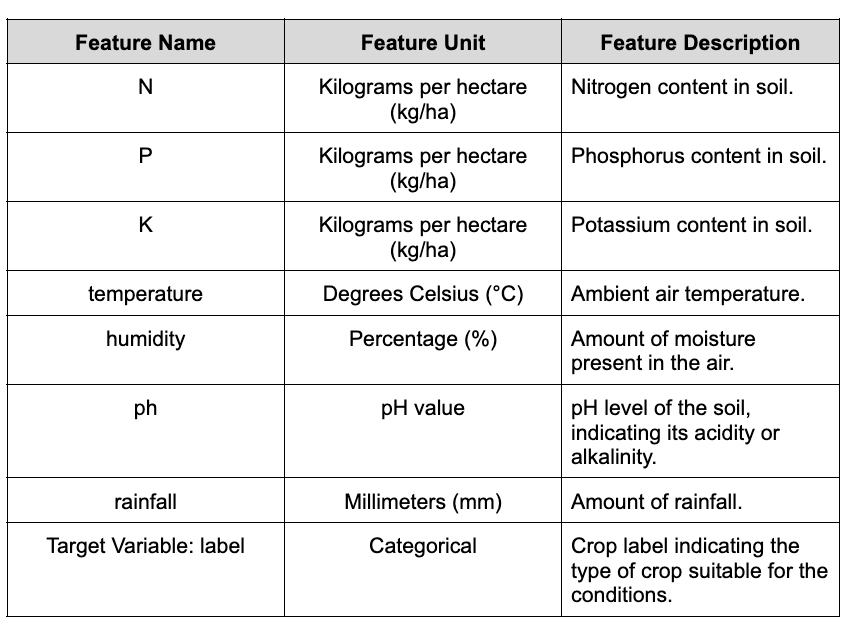

The crops included in the dataset are diverse, comprising 22 different types, such as rice, maize, chickpea, kidney beans, pigeon peas, and more. This variety enhances the dataset's applicability across different agricultural contexts and regions.

1. Apple
2. Banana
3. Black gram
4. Chickpea
5. Coconut
6. Coffee
7. Cotton
8. Grapes
9. Jute
10. Kidney beans
11. Lentil
12. Maize
13. Mango
14. Moth beans
15. Mung bean
16. Musk Melon
17. Orange
18. Papaya
19. Pigeon Peas
20. Pomegranate
21. Rice
22. Watermelon

The total number of data points allows for a comprehensive analysis of how varying environmental conditions impact crop recommendations, making it a valuable resource for developing predictive models. The dataset is publicly available, ensuring transparency and credibility, as it has been sourced from reputable agricultural databases.

### b. Feature Selection and Justification

All features included in this study will be utilized as they are specifically relevant to the task of crop recommendation and have been preprocessed by the dataset owner. The dataset includes critical environmental variables such as soil nutrient ratios (Nitrogen, Phosphorus, Potassium), pH levels, temperature, humidity, and rainfall, which are essential for understanding crop suitability.

In this research, a combination of qualitative and algorithmic approaches will be employed for feature selection. The qualitative approach involves reviewing existing literature to understand how previous studies have selected their features and crops for analysis. This literature review will provide insights into best practices and established methodologies in the field of agricultural data science.

On the other hand, an algorithmic approach will also be adopted, primarily through Exploratory Data Analysis (EDA). EDA will facilitate the identification of relationships between the environmental features and crop recommendations, allowing for a more data-driven selection process. Techniques such as correlation analysis and visualizations (e.g., scatter plots) will be employed to assess the strength of associations between features and the target variable.

Additionally, feature importance metrics from machine learning models will be utilized to further refine the selection process. By evaluating how each feature contributes to model predictions, we can ensure that only the most relevant variables are retained for final analysis. This dual approach—leveraging both qualitative insights and quantitative metrics—will be crucial in finalizing a robust dataset that enhances model performance while minimizing redundancy.

### c. Research Question

The study aims to uncover the intricacies of how environmental factors such as nitrogen, humidity, and rainfall impact crop growth thereby providing valuable insights for agricultural decision making and sustainability. With that, the study aims to answer the following research question:

*What is the most optimal machine learning classification model for crop prediction given various environmental conditions and which features significantly influence crop predictions?*

# II. List of Requirements

The dataset used in the project was sourced from Kaggle. Atharva Ingle is the owner of the dataset which was updated 4 years ago.

Crop Recommendation Dataset - Kaggle

The packages used in the study can be divided into multiple categories based on use.

Data Manipulation - These libraries were used in the manipulation of the dataset throughout the notebook

1. **Pandas**
2. **Numpy**

Visualization - These libraries were used in the visualization of data and model results

1. **Matplotlib**
2. **Matplotlib.pyplot**
3. **Seaborn**
4. **Plotly**
5. **plotly.express**

Machine Learning Related (Scikit Learn) - These libraries were used in the model implementation. This included importing the machine models themselves, and for data preprocessing, feature selection, and model result evaluation

1. **Sklearn.model_selection**
   - Train_test_split
   - GridSearchCV
   - RandomizedSearchCV
2. **Sklearn.preprocessing**
   - StandardScaler
3. **Sklearn.tree**
   - DecisionTreeClassifier
4. **Sklearn.linear_model**
   - RidgeClassifier
5. **Sklearn.ensemble**
   - GradientBoostingClassifier
   - RandomForestClassifier
6. **Sklearn.gaussian_process**
   - GaussianProcessClassifier
7. **Sklearn.inspection**
   - Permutation_importance

Time Series - These libraries were used for determining if the dataset had inherent temporal components

1. **Statsmodels.tsa.stattools**
2. **adfuller**

TensorFlow and Keras - These libraries were used in the implementation of the TensorFlow machine learning models and neural networks, and for implementing Keras’s preprocessing laters

1. **Tensorflow**
   - Tensorflow
2. **Tensorflow.keras**
   - Layers
3. **Tensorflow_decision_forests**
   - Tensorflow_decision_forests

# III. Review of Related Literature

A study by Shinde et al. (2023) entitiled **"Smart Farming: Crop Recommendation using Machine Learning with Challenges and Future Ideas"**, has looked into a crop recommendation system that utilizes similar machine learning classification techniques. This study explores the use of machine learning algorithms to automate crop recommendations, leveraging features like soil composition and climate data to help farmers make informed decisions, ultimately aiming to enhance crop yields. Moreover, the study employed various classification algorithms, including Logistic Regression, Decision Tree, Random Forest, K-Nearest Neighbors, Naive Bayes, Support Vector Machine (SVM), and Neural Networks, to analyze and predict the best crops for specific agricultural conditions. According to the authors of this study, the best model is the Random Forest, model outperformed others in terms of accuracy, indicating its effectiveness for crop recommendation tasks.

Another study by Kiran et al. (2024) entitled **"A Machine Learning Enabled System for Crop Recommendation"**, looked into a similar crop recommendation system. They employed various machine learning classification techniques, including Gaussian Naïve Bayes (GNB), Random Forest (RF), Decision Tree (DT), K-Nearest Neighbor (KNN), and Logistic Regression (LR), to predict crop yields and optimize agricultural practices. As for this study, the best model identified in the study is the Gaussian Naïve Bayes (GNB) classifier, which achieved accuracy of 99% in predicting crop yields.

# IV. Methodology

The methodology employs supervised machine learning techniques, specifically classifiers, to analyze various crops and specific environmental measures and conditions. The models to be utilized are the following: *(1)* Decision Tree, *(2)* Ridge Classifier, *(3)* Gaussian Process Classifier, *(4)* Gradient Boosting Classifier, *(5)* Tensor Flow Decision Forest, *(6)* Keras Pre-Processing Layers. Additionally, SHAP, PDP, and the Proportional Chance Criterion (PCC) will be utilized on providing additional metrics for each model given 3 top selected crops in relation to the context of India given the dataset. Unlike previous studies that often treat these attributes in isolation or rely on simplistic segmentation methods, this approach integrates a robust data-driven framework emphasizing predictive accuracy and interpretability.

## a. Data Exploration Strategies

Despite the dataset already being pre-processed by the uploaders of the dataset, it will still be vital to pre-process the dataset based on the specific context and needs of the study. Initially, the dataset can be scrutinized first by checking for null values and the data types of the features. Scatterplots can be deployed between the dependent and independent variables to get a general insight about the relationship between these variables before proceeding with the regression. On the other hand, Box Plots will be employed to measure the amount of outlies in a specific feature. Moreover, the integration of initial EDA analysis could give a glimpse of whether or not there would be potential outliers on the dataset. The EDA could also be used to further understand the dataset before proceeding with the model implementation.

## b. Justification for the Methodology Choice

**Decision Tree (Base Model)**

Decision trees are widely used for crop recommendation in classification tasks because they are easy to interpret and can handle both numerical and categorical data, making them suitable for agricultural datasets. They divide data into distinct groups by learning simple decision rules, making them effective for understanding relationships between environmental factors (like soil characteristics, rainfall, and temperature) and crop suitability. Decision trees serve as a base model because they are computationally efficient, providing a quick and clear baseline performance for comparison with more complex models.

**Ridge Classifier**

Ridge Classifier uses L2 regularization to build a linear model that predicts the most suitable crop for given environmental conditions. By penalizing overly complex relationships, it ensures robust recommendations even with high-dimensional environmental data. For instance, it can handle correlated variables like the ratios of Nitrogen, Phosphorus, and Potassium in soil, ensuring that the model remains stable while interpreting their combined effects. This makes it a good choice for initial analyses when the goal is to identify linear patterns between environmental factors and crop suitability.

**Gradient Boosting Classifier**

Gradient Boosting Classifier creates an ensemble of decision trees, progressively improving predictions of the ideal crop for specific environmental conditions. Each tree refines the errors of the previous ones, resulting in a highly accurate recommendation system for complex datasets. For example, it can capture non-linear interactions between variables such as how temperature and humidity together influence crop growth. Its ability to focus on correcting errors makes it highly effective in tailoring recommendations for regions with unique environmental profiles.

**Gaussian Process Classifier**

Gaussian Process Classifier models the relationship between environmental factors and crop suitability probabilistically, providing predictions along with confidence intervals. This makes it effective in determining the best crop while accounting for uncertainty in variable conditions. For example, it can quantify how confidently the model predicts a crop recommendation under extreme rainfall variability or fluctuating soil pH conditions. This probabilistic insight is valuable in guiding decisions with inconsistent or poorly documented environmental data.

**Tensor Flow Random Forest**

TensorFlow Random Forest combines tree-based algorithms with TensorFlow's ecosystem to recommend the best crop for specific environmental conditions. It integrates seamlessly with deep learning workflows, offering both interpretability and flexibility in handling diverse datasets.

**Tensor Flow Keras Pre-Processing Layers**

Keras Preprocessing Layers prepare environmental data, such as scaling soil pH or normalizing temperature values, for input into crop classification models. These layers enable efficient and real-time preprocessing during model training, ensuring the data aligns with the model's requirements.

**Proportional Chance Criterion (PCC)**

The proportional chance criterion is essential for multiclassification tasks in machine learning because it provides a baseline accuracy that accounts for the class distribution in the dataset. Unlike a fixed threshold, this criterion adjusts for imbalanced data by considering the likelihood of correctly predicting a class purely by chance, weighted by its frequency. This helps to evaluate whether a model's performance genuinely reflects learning patterns or simply the skewness in class proportions. Using this as a baseline or benchmark ensures a more fair and meaningful assessment of the model's predictive capabilities in multiclass settings.

**Shapley Additive Explanations (SHAP)**

SHAP (SHapley Additive exPlanations) is essential because it provides a unified framework for interpreting the contributions of individual features to a machine learning model's predictions. It ensures consistency and fairness by attributing importance to features based on their marginal contributions across all possible feature combinations, rooted in cooperative game theory. This makes SHAP particularly valuable for understanding complex, black-box models, as it delivers clear, locally faithful explanations for individual predictions. By enhancing transparency, SHAP fosters trust, especially in critical applications like healthcare, and agriculture.

**Partial Dependence Plots (PDP)**

Partial Dependence Plots (PDPs) are essential in machine learning as they illustrate the relationship between a feature and the predicted outcome while marginalizing over the effects of other features. This helps to visualize how a specific feature influences predictions, providing insights into model behavior. PDPs are particularly valuable for complex, black-box models like ensembles or neural networks, where understanding feature contributions is challenging.

## c. Hypothesis Development

**Null Hypothesis (H0):** None of the environmental factors in the dataset significantly contribute to the accuracy of crop predictions across different machine learning models.

**Alternative Hypothesis (H1):** Certain features in the dataset significantly contribute to the accuracy of crop predictions across different machine learning models.

## d. Project Workflow

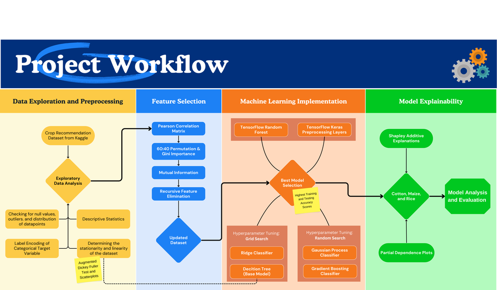

Our project will undergo four major phases. The first is Data Exploration and Preprocessing wherein the dataset will be checked for missing values, proper distribution of classes, presence of outliers, stationarity and linearity of the features, and categorical features that need to be numerically encoded. The second phase is the Feature Selection process of selecting a subset of relevant features from a dataset and removing features that are not to improve model accuracy and predictions. The third phase is the actual implementation of the chosen Machine learning models mentioned previously. A best model based on the highest training and testing accuracy scores will be selected from the selected models. Proportional Chance Criterion will also be used as the baseline accuracy for all of the models’ accuracy to exceed for it to be considered meaningful. Lastly, after choosing the best model, the last phase is Model Explainability wherein the best model is subjected to SHapley Additive exPlanations and Partial Dependence Plots to further dissect the interactions between the features and the target variable and determine how the individual predictions are influenced by the features.

*Author's Note*

Initially, the authors wanted to try **Logistic Regression**, however, given the nature of the dataset (non-stationary & non-linear), the authors opted to drop this model. According to Navlani (2024), logistic regression assumes a linear relationship between the input variables and the logs of the outcomes. Given the status of non-linear data, this results in poor performance unless it is addressed with extensive feature engineering. Additionally, the model cannot capture the full complexity of the relationships, leading to high bias, which is why it is linked to poor performance.

Additionally, according to Ellis (2022), in non-stationary datasets, wherein statistical properties such as mean and variance change over time, could undermine logistic regression. The model assumes a static relationship between input features and outcomes, which is unrealistic for non-stationary and non-linear datasets. Given this, the model would likely underperform unless it would be retrained frequently. Moreover, logistic regression struggles with highly correlated features, irrelevant variables in the dataset, and those not strongly related and linked to the target variable. These issues and characteristics are usually common in non-stationary data, which implies that it can further degrade its model performance.

# V. Data Exploration and Preprocessing

```python
pip install shap
```

```python
# Import necessary library packages
import pandas as pd
import numpy as np
import matplotlib.pyplot as plt
import shap
import seaborn as sns
from sklearn import preprocessing
import plotly.express as px
from sklearn.model_selection import train_test_split, GridSearchCV, RandomizedSearchCV
from sklearn.preprocessing import StandardScaler
from sklearn.tree import DecisionTreeClassifier
from sklearn.linear_model import RidgeClassifier
from sklearn.ensemble import GradientBoostingClassifier
from sklearn.gaussian_process import GaussianProcessClassifier
from sklearn.ensemble import RandomForestClassifier
from sklearn.inspection import permutation_importance
from sklearn.linear_model import LogisticRegression
from sklearn.metrics import classification_report, accuracy_score, confusion_matrix
from statsmodels.tsa.stattools import adfuller
from sklearn.feature_selection import RFE, RFECV
from sklearn.feature_selection import mutual_info_classif
from scipy.stats import uniform
from sklearn.gaussian_process.kernels import RBF, ConstantKernel as C
```

```python
# Load the dataset
df = pd.read_csv('https://raw.githubusercontent.com/GertFriborg/Data/refs/heads/main/DATA103/Crop_recommendation.csv')
df.head()
```

|  | N | P | K | temperature | humidity | ph | rainfall | label |
| --- | --- | --- | --- | --- | --- | --- | --- | --- |
| 0 | 90 | 42 | 43 | 20.879744 | 82.002744 | 6.502985 | 202.935536 | rice |
| 1 | 85 | 58 | 41 | 21.770462 | 80.319644 | 7.038096 | 226.655537 | rice |
| 2 | 60 | 55 | 44 | 23.004459 | 82.320763 | 7.840207 | 263.964248 | rice |
| 3 | 74 | 35 | 40 | 26.491096 | 80.158363 | 6.980401 | 242.864034 | rice |
| 4 | 78 | 42 | 42 | 20.130175 | 81.604873 | 7.628473 | 262.717340 | rice |

We check the data types of each variable, as well as the shape of the dataset.

```python
# Check for the datatypes of the features
df.info()
```

```
<class 'pandas.core.frame.DataFrame'>
RangeIndex: 2200 entries, 0 to 2199
Data columns (total 8 columns):
 #   Column       Non-Null Count  Dtype
---  ------       --------------  -----
 0   N            2200 non-null   int64
 1   P            2200 non-null   int64
 2   K            2200 non-null   int64
 3   temperature  2200 non-null   float64
 4   humidity     2200 non-null   float64
 5   ph           2200 non-null   float64
 6   rainfall     2200 non-null   float64
 7   label        2200 non-null   object
dtypes: float64(4), int64(3), object(1)
memory usage: 137.6+ KB
```

We then check the basic descriptive statistics of the dataset to see if there is anything that stands out.

```python
# Check the Descriptive Statistics of the Dataset
df.describe()
```

|  | N | P | K | temperature | humidity | ph | rainfall |
| --- | --- | --- | --- | --- | --- | --- | --- |
| count | 2200.000000 | 2200.000000 | 2200.000000 | 2200.000000 | 2200.000000 | 2200.000000 | 2200.000000 |
| mean | 50.551818 | 53.362727 | 48.149091 | 25.616244 | 71.481779 | 6.469480 | 103.463655 |
| std | 36.917334 | 32.985883 | 50.647931 | 5.063749 | 22.263812 | 0.773938 | 54.958389 |
| min | 0.000000 | 5.000000 | 5.000000 | 8.825675 | 14.258040 | 3.504752 | 20.211267 |
| 25% | 21.000000 | 28.000000 | 20.000000 | 22.769375 | 60.261953 | 5.971693 | 64.551686 |
| 50% | 37.000000 | 51.000000 | 32.000000 | 25.598693 | 80.473146 | 6.425045 | 94.867624 |
| 75% | 84.250000 | 68.000000 | 49.000000 | 28.561654 | 89.948771 | 6.923643 | 124.267508 |
| max | 140.000000 | 145.000000 | 205.000000 | 43.675493 | 99.981876 | 9.935091 | 298.560117 |

With these information from the descriptive statistics, several insights can be drawn. First, by correlating nutrient levels and climatic factors with optimal growth conditions fro various crops, targeted recommendations can be developed to enhance productivity. Second, analyzing nutrient data (N, P, K) can help formulate models that predic optimal fertilizer application rates tailored to specific soil conditions. Third, variability in temperature and rainfall can be leveraged for studies assessing the potential impacts of climate change on agricultural practices and crop resilience. Lastly, farmers can be advised on managing pH extremes or nutrient imbalances to improve soil health and crop performance.

From the information above, there is a need to encode the target variable, which is Label that consists of the classification of the crops.

We then check for any null values in the dataset which we may need to impute or drop.

```python
# Check for missing values
df.isna().sum()
```

|  | 0 |
| --- | --- |
| N | 0 |
| P | 0 |
| K | 0 |
| temperature | 0 |
| humidity | 0 |
| ph | 0 |
| rainfall | 0 |
| label | 0 |

**dtype:** int64

Given that there are none, we then proceed to checking if there are any outliers in the numerical variables of our dataset.

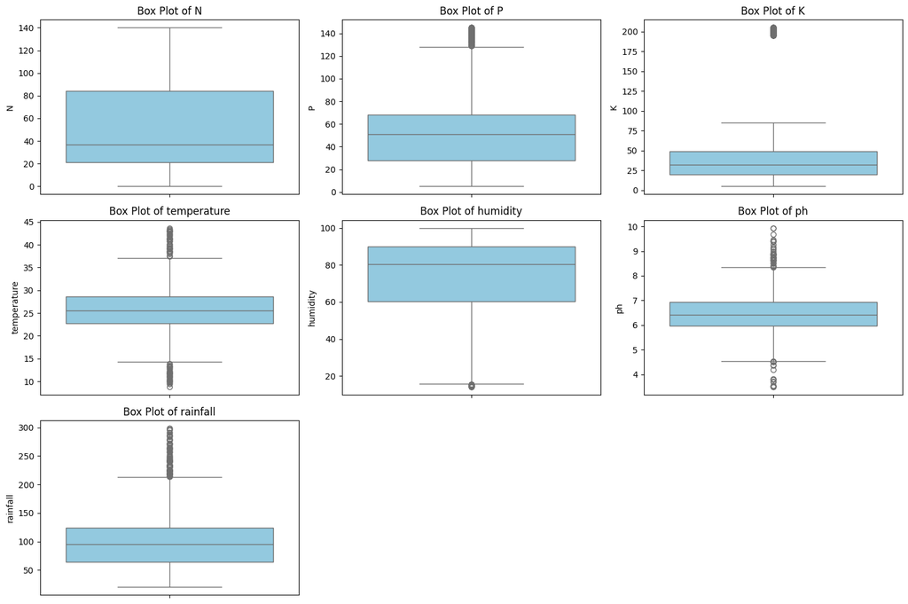

```python
# Create for outliers of all numerical features using box plots
numerical_features = df.select_dtypes(include=['float64', 'int64']).columns

plt.figure(figsize=(15, 10))
for i, feature in enumerate(numerical_features, 1):
    plt.subplot(3, 3, i)
    sns.boxplot(y=df[feature], color="skyblue")
    plt.title(f'Box Plot of {feature}')
    plt.tight_layout()
plt.show()
```

From the boxplot, we see that there seems to be many outliers in the P, K, temperature, humidity, ph, and rainfall variables. We will however choose NOT to drop theese outlier values as we suspect that these arise due to the specific needs of a certain crop. For example, a potato may need an extremely basic ph level compared to other crops, or rice needs much more rainfall and humidity than others, etc.

Then we check for any hidden stationarity of the data by implementing the Augmented-Dickey Fuller Test. If the p-value returned is less than the critical value, we conclude that the data is stationary.

```python
# Function to check stationarity with ADF test and visualize rolling mean/variance
def check_stationarity(df, columns):
    for column in columns:
        print(f"\nChecking stationarity for: {column}")

        # ADF Test
        result = adfuller(df[column])
        print("ADF Statistic:", result[0])
        print("p-value:", result[1])
        print("Critical Values:", result[4])

# Apply stationarity check for numerical features
check_stationarity(df, numerical_features)
```

```
Checking stationarity for: N
ADF Statistic: -2.9864740915975085
p-value: 0.03617700293083439
Critical Values: {'1%': -3.4333353948342364, '5%': -2.8628588504396624, '10%': -2.5674720888708404}

Checking stationarity for: P
ADF Statistic: -4.196101044612285
p-value: 0.0006689853228258604
Critical Values: {'1%': -3.4333326714656223, '5%': -2.8628576479452597, '10%': -2.5674714486226202}

Checking stationarity for: K
ADF Statistic: -3.439219367800408
p-value: 0.009692368129893146
Critical Values: {'1%': -3.4333285957162567, '5%': -2.8628558483095645, '10%': -2.5674704904367522}

Checking stationarity for: temperature
ADF Statistic: -3.1921479539371616
p-value: 0.020443709118380032
Critical Values: {'1%': -3.4333629045681398, '5%': -2.8628709972102797, '10%': -2.567478556227762}

Checking stationarity for: humidity
ADF Statistic: -1.9676007388273906
p-value: 0.3009571740475763
Critical Values: {'1%': -3.4333518400589074, '5%': -2.8628661117509484, '10%': -2.567475955039574}

Checking stationarity for: ph
ADF Statistic: -3.723842054959533
p-value: 0.0037900221707962566
Critical Values: {'1%': -3.4333601308010926, '5%': -2.8628697724738688, '10%': -2.5674779041352886}

Checking stationarity for: rainfall
ADF Statistic: -3.389530141620072
p-value: 0.011321008714268437
Critical Values: {'1%': -3.4333629045681398, '5%': -2.8628709972102797, '10%': -2.567478556227762}
```

The Augmented Dickey Fuller Test tests for the stationarity of the features. If the p-value is less than 0.05, then the feature is stationary and if the p-value is more than 0.05, then it is not stationary. From the results above, it can be seen that humidity is not stationary while the rest of the features are stationary. It is important to determine the stationarity of the features since this will dictate if the base model of the project is a Logistic Regression or Decision Tree based on these results as Logistic Regression is a parametric model that assumes that features are stationary and linear.

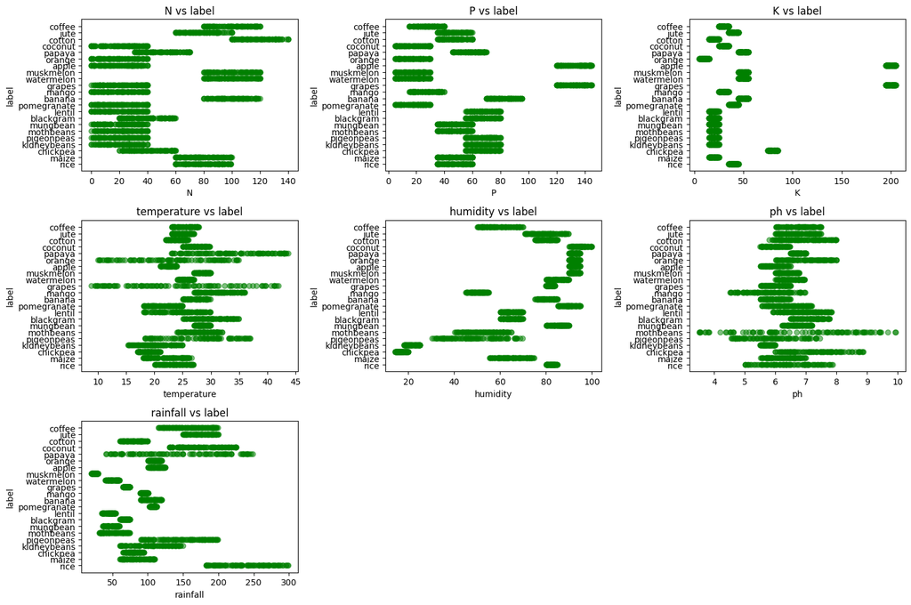

```python
# Determine the target variable
target_column = 'label'

# Plot scatterplots to check linearity
plt.figure(figsize=(15, 10))
for i, feature in enumerate(numerical_features, 1):
    plt.subplot(3, 3, i)
    plt.scatter(df[feature], df[target_column], alpha=0.5, color='green')
    plt.title(f'{feature} vs {target_column}')
    plt.xlabel(feature)
    plt.ylabel(target_column)
    plt.tight_layout()
plt.show()
```

From the scatterplots above, it can be inferred that most of the features are non-linear since they don't exhibit a straight pattern and are mostly spread out. Given the results of the Augmented Dickey Fuller Test and scatterplots, the base model should be a Decision Tree to accomodate the non-linearity of features and non-stationary of humidity feature.

# VI. Feature Extraction and Selection

Before we proceed with the implementation of the machine learning models, we first perform feature extraction and selection in order to see which features will actually be included as inputs in the machine learning models.

### a. Label Encoding

We proceed with label-encoding the data using scikitlearn preprocessing's LabelEncoder(). This is done to prepare the data before feeding it into the machine learning models.

```python
# Initialize the label encoder
label_encoder = preprocessing.LabelEncoder()

# Fit the encoder on the categorical column
label_encoder.fit(df['label'])

# Save the mapping of categorical values to numbers
label_mapping = dict(zip(label_encoder.classes_, label_encoder.transform(label_encoder.classes_)))

# Optionally, store it as a DataFrame for easier access
mapping_df = pd.DataFrame(list(label_mapping.items()), columns=['Category', 'Encoded Value'])

# Proceed with label encoding
df['label'] = label_encoder.transform(df['label'])

# Print the mapping
print(mapping_df)
```

```
       Category  Encoded Value
0         apple              0
1        banana              1
2     blackgram              2
3      chickpea              3
4       coconut              4
5        coffee              5
6        cotton              6
7        grapes              7
8          jute              8
9   kidneybeans              9
10       lentil             10
11        maize             11
12        mango             12
13    mothbeans             13
14     mungbean             14
15    muskmelon             15
16       orange             16
17       papaya             17
18   pigeonpeas             18
19  pomegranate             19
20         rice             20
21   watermelon             21
```

We inspect df one last time and verify that our preprocessing techniques have been correctly implemented.

```python
# Check the updated dataframe
df
```

|  | N | P | K | temperature | humidity | ph | rainfall | label |
| --- | --- | --- | --- | --- | --- | --- | --- | --- |
| 0 | 90 | 42 | 43 | 20.879744 | 82.002744 | 6.502985 | 202.935536 | 20 |
| 1 | 85 | 58 | 41 | 21.770462 | 80.319644 | 7.038096 | 226.655537 | 20 |
| 2 | 60 | 55 | 44 | 23.004459 | 82.320763 | 7.840207 | 263.964248 | 20 |
| 3 | 74 | 35 | 40 | 26.491096 | 80.158363 | 6.980401 | 242.864034 | 20 |
| 4 | 78 | 42 | 42 | 20.130175 | 81.604873 | 7.628473 | 262.717340 | 20 |
| ... | ... | ... | ... | ... | ... | ... | ... | ... |
| 2195 | 107 | 34 | 32 | 26.774637 | 66.413269 | 6.780064 | 177.774507 | 5 |
| 2196 | 99 | 15 | 27 | 27.417112 | 56.636362 | 6.086922 | 127.924610 | 5 |
| 2197 | 118 | 33 | 30 | 24.131797 | 67.225123 | 6.362608 | 173.322839 | 5 |
| 2198 | 117 | 32 | 34 | 26.272418 | 52.127394 | 6.758793 | 127.175293 | 5 |
| 2199 | 104 | 18 | 30 | 23.603016 | 60.396475 | 6.779833 | 140.937041 | 5 |

2200 rows × 8 columns

### b. Pearson Correlation Matrix

Moving on, we plot a correlation matrix of all the variables. If the values inside the matrix column is closer to -1 or 1, it means that the variables on the row and column indexes of the matrix are either negatively or positively corrrelated, with a score of 0 meaning no correlation between the variables. Any type of correlation will affect the performance of the machine learning model, and so correlated variabels must be dealt with.

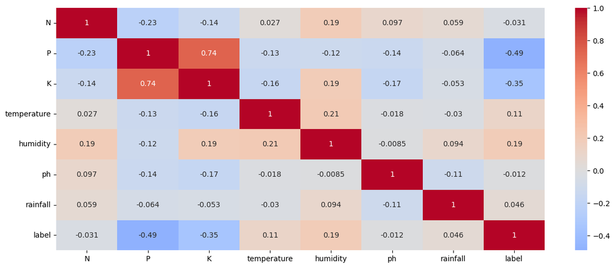

```python
# Implement Pearson Correlation Matrix
df_corr = df.corr()
plt.figure(figsize=(15,6))
sns.heatmap(df_corr, annot=True,  cmap="coolwarm", center=0)
plt.show()
```

Pearson correlation matrix revealed a positive 0.74 coefficient between K and P. All the other features do not have a significant correlation with each other.

### c. 60:40 Permutation and Gini Importance

```
       Feature  Permutation Importance (60%)  Gini Importance (40%)  \
4     humidity                      0.195818               0.084511
6     rainfall                      0.104045               0.090814
2            K                      0.113591               0.072489
0            N                      0.108000               0.043544
1            P                      0.069000               0.057449
3  temperature                      0.005318               0.030273
5           ph                      0.005182               0.020920

   Combined Score
4        0.280330
6        0.194860
2        0.186080
0        0.151544
1        0.126449
3        0.035591
5        0.026102
```

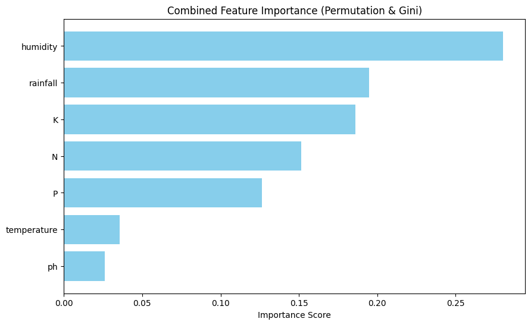

```python
# Implement Random Forest Feature Importance with weights (60% from Permutation Importance and 40% from Gini Importance)

# Load dataset and define X (features) and y (target)
X = df.drop('label', axis=1)
y = df['label']

# Train-Test Split
X_train, X_test, y_train, y_test = train_test_split(X, y, test_size=0.2, random_state=42)

# Model: Random Forest
rf = RandomForestClassifier(n_estimators=100, random_state=42)
rf.fit(X_train, y_train)


# -------------------------- #
# 1. Permutation Importance
# -------------------------- #
perm_importance = permutation_importance(rf, X_test, y_test, n_repeats=10, random_state=42)

# Get the feature importance values and scale to 60%
perm_scores = perm_importance.importances_mean * 0.60

# -------------------------- #
# 2. Gini Importance (from Random Forest)
# -------------------------- #
gini_scores = rf.feature_importances_ * 0.40

# -------------------------- #
# 3. Combine and Rank the Scores
# -------------------------- #
# Combine both scores
combined_scores = perm_scores + gini_scores

# Create DataFrame to store and rank features
feature_importance_df = pd.DataFrame({
    'Feature': X.columns,
    'Permutation Importance (60%)': perm_scores,
    'Gini Importance (40%)': gini_scores,
    'Combined Score': combined_scores
})

# Sort by combined score to rank features by importance
feature_importance_df = feature_importance_df.sort_values(by='Combined Score', ascending=False)

# Display the ranked features
print(feature_importance_df)

# -------------------------- #
# Plot the Combined Importance
# -------------------------- #
plt.figure(figsize=(10,6))
plt.barh(feature_importance_df['Feature'], feature_importance_df['Combined Score'], color='skyblue')
plt.xlabel('Importance Score')
plt.title('Combined Feature Importance (Permutation & Gini)')
plt.gca().invert_yaxis()
plt.show()
```

For the feature importance which is composed of the combined scores of Permutation Importance and Gini Importance with 60% and 40% weights associated with their scores respectively, the top scorers are humidity and rainfall while the lowest scores are from temperature and ph

The reason for doing both Gini and Permutation is because both feature importance has its disadvantages so combining their scores creates a more balanced feature importance. Gini Importance disadvantage: it does not take into account feature correlation and also it has biases towards numerical features with more unique values. If two highly correlated features are both equally important for predicting the outcome variable, one of those features may have low Gini-based importance because all of it’s explanatory power was ascribed to the other feature. With Permutation Importance, it measures the impact of shuffling feature values, offering insights into the true predictive power and covers the weakness of Gini Importance.

### d. Mutual Information

```python
# Mutual Information

# Compute mutual information scores
mi_scores = mutual_info_classif(X, y)

# Create a DataFrame for mutual information scores
mi_df = pd.DataFrame({'Feature': X.columns, 'MI Score': mi_scores})

# Sort by MI score
mi_df = mi_df.sort_values(by='MI Score', ascending=False)
print(mi_df)
```

```
       Feature  MI Score
4     humidity  1.729954
6     rainfall  1.637358
2            K  1.625535
1            P  1.315784
3  temperature  1.017901
0            N  0.985656
5           ph  0.686067
```

for Mutual Information, the top scorers are humidity, Potassium, and Rainfall while the lowest scores are from Nitrogen and ph

Mutual Information Justification: Measures both linear and non-linear dependencies between features and the target, capturing broader relationships compared to Pearson correlation. The dataset have non-linear features, which may prove to be more effective at capturing relationships than Pearson correlation.

### e. Recursive Feature Elimination

Recursive Feature Elimination Justification: Recursive Feature Elimination is more of an iterative process of feature selection and also determine where the accuracy peaks as more features are added, so including this supplements the feature selection.

```python
# Define the estimator
estimator = GradientBoostingClassifier()

# You may experiment with other estimators, but Gradient Boosting Classifier will be used as an example
#estimator = LogisticRegression()
#estimator = DecisionTreeClassifier()
#estimator = RandomForestClassifier()

# Implement Recursive Feature Elimination
selector = RFE(estimator, n_features_to_select=7, step=1)
selector.fit(X_train, y_train)
```

```
RFE(estimator=GradientBoostingClassifier(), n_features_to_select=7)
```

```python
X_train.columns[selector.get_support()]
```

```
Index(['N', 'P', 'K', 'temperature', 'humidity', 'ph', 'rainfall'], dtype='object')
```

```python
rfecv = RFECV(estimator=estimator, scoring='accuracy', min_features_to_select=3)
rfecv.fit(X, y)
```

```
RFECV(estimator=GradientBoostingClassifier(), min_features_to_select=3,
      scoring='accuracy')
```

```python
rfecv.cv_results_
```

```
{'mean_test_score': array([0.94909091, 0.96772727, 0.98863636, 0.98863636, 0.99090909]),
 'std_test_score': array([0.00904534, 0.00913625, 0.00518262, 0.00406558, 0.00321412]),
 'split0_test_score': array([0.94545455, 0.95681818, 0.98636364, 0.99090909, 0.99090909]),
 'split1_test_score': array([0.94772727, 0.96818182, 0.98863636, 0.98636364, 0.98863636]),
 'split2_test_score': array([0.93863636, 0.95909091, 0.98863636, 0.99318182, 0.99318182]),
 'split3_test_score': array([0.96590909, 0.98181818, 0.99772727, 0.99090909, 0.99545455]),
 'split4_test_score': array([0.94772727, 0.97272727, 0.98181818, 0.98181818, 0.98636364]),
 'n_features': array([3, 4, 5, 6, 7])}
```

```python
list(range(1,len(rfecv.cv_results_['mean_test_score'])+1))
```

```
[1, 2, 3, 4, 5]
```

[figure not shown]

```python
# Plot the trend of accuracy as more features are added
ax = sns.lineplot(x=list(range(1,len(rfecv.cv_results_['mean_test_score'])+1)),
                  y=list(rfecv.cv_results_['mean_test_score']))
ax.set_title("Accuracy vs # of Features")
ax.set_xlabel("# of Features")
ax.set_ylabel("Accuracy")
```

```python
X_train.columns
```

```
Index(['N', 'P', 'K', 'temperature', 'humidity', 'ph', 'rainfall'], dtype='object')
```

```python
rfecv.support_
```

```
array([ True,  True,  True,  True,  True,  True,  True])
```

The result above tells us that all features are relevant using the Recursive Feature Elimination

```python
temp_df = pd.DataFrame()
temp_df['feature'] = X_train.columns
temp_df['rank'] = rfecv.ranking_
temp_df_sorted = temp_df.sort_values(by='rank', ascending=True)
temp_df_sorted
```

|  | feature | rank |
| --- | --- | --- |
| 0 | N | 1 |
| 1 | P | 1 |
| 2 | K | 1 |
| 3 | temperature | 1 |
| 4 | humidity | 1 |
| 5 | ph | 1 |
| 6 | rainfall | 1 |

The ranking above tells us that all features are equally important.

From the feature selection results above, it can be inferred that humidity has been a consistent top feature importance with rainfall following its lead. Other features exhibit mixed results. ph has been a consistent low scorer in the feature selection methods.

**On Why pH is Insignificant in Growing Crops**

Research has shown that focusing on key nutrients rather than strictly managing soil pH can lead to successful crop production. For instance, ensuring adequate nitrogen levels may be more critical than maintaining a specific pH level for certain crops (Prabavathi et al, 2024). While it has been proven that soil pH affects the solubility and availability of essential nutrients, it may not be the sole determinant of crop health. In some cases, certain nutrients like phosphorus are most available at a pH of around 6.5. However, crops can still thrive within a broader pH range if other nutrients are adequately supplied (Dobbins, 2021).

Complex interactions between soil nutrients and plant growth may also affect these findings. In some cases, high nutrient availability can compensate for suboptimal pH levels. Hence, if feature selection analysis indicates that pH is less important for specific crops in the dataset, it could be due to these compensatory mechanisms at play (Tababa, 2023).

Due to its low feature importance score, ph feature will be dropped to further improve the accuracy and prediction of the models.

```python
# Drop ph
df = df.drop(columns=['ph'])
```

```python
# Check the distribution of classes in the target variable
df['label'].value_counts()
```

| label | count |
| --- | --- |
| 20 | 100 |
| 11 | 100 |
| 8 | 100 |
| 6 | 100 |
| 4 | 100 |
| 17 | 100 |
| 16 | 100 |
| 0 | 100 |
| 15 | 100 |
| 21 | 100 |
| 7 | 100 |
| 12 | 100 |
| 1 | 100 |
| 19 | 100 |
| 10 | 100 |
| 2 | 100 |
| 14 | 100 |
| 13 | 100 |
| 18 | 100 |
| 9 | 100 |
| 3 | 100 |
| 5 | 100 |

**dtype:** int64

Undersampling and Oversampling will not be applied since the dataset is already balanced.

```python
# Check the updated dataset to be used in the models
df
```

|  | N | P | K | temperature | humidity | rainfall | label |
| --- | --- | --- | --- | --- | --- | --- | --- |
| 0 | 90 | 42 | 43 | 20.879744 | 82.002744 | 202.935536 | 20 |
| 1 | 85 | 58 | 41 | 21.770462 | 80.319644 | 226.655537 | 20 |
| 2 | 60 | 55 | 44 | 23.004459 | 82.320763 | 263.964248 | 20 |
| 3 | 74 | 35 | 40 | 26.491096 | 80.158363 | 242.864034 | 20 |
| 4 | 78 | 42 | 42 | 20.130175 | 81.604873 | 262.717340 | 20 |
| ... | ... | ... | ... | ... | ... | ... | ... |
| 2195 | 107 | 34 | 32 | 26.774637 | 66.413269 | 177.774507 | 5 |
| 2196 | 99 | 15 | 27 | 27.417112 | 56.636362 | 127.924610 | 5 |
| 2197 | 118 | 33 | 30 | 24.131797 | 67.225123 | 173.322839 | 5 |
| 2198 | 117 | 32 | 34 | 26.272418 | 52.127394 | 127.175293 | 5 |
| 2199 | 104 | 18 | 30 | 23.603016 | 60.396475 | 140.937041 | 5 |

2200 rows × 7 columns

# VII. Implementation of Machine Learning models

Before we implement the machine learning models, we must separate them into training and testing sets. The training sets will be used to train the model while the testing sets will be used as a performance check to see how well the model is able to generalize on unseen data given its training on the training data.

```python
# Define the features in X and the target variable in y
X = df.drop('label', axis=1)
y = df['label']

# Train-Test Split (80% Training and 20% Testing)
X_train, X_test, y_train, y_test = train_test_split(X, y, test_size=0.2, random_state=42)

# Standardize Features
scaler = StandardScaler()
X_train_scaled = scaler.fit_transform(X_train)
X_test_scaled = scaler.transform(X_test)
```

## Decision Forest - Base Model

We will perform grid search for this to find the best parameters that maximize accuracy.

```python
# Define the hyperparameter grid
param_grid = {
    'criterion': ['gini', 'entropy','log_loss'],       # Splitting criteria
    'max_depth': [None, 3, 5, 10, 20, 30],             # Maximum depth of the tree
    'min_samples_split': [2, 5, 10],                   # Minimum samples to split a node
    'min_samples_leaf': [1, 2, 4],                     # Minimum samples per leaf
}

# Initialize Grid Search
grid = GridSearchCV(DecisionTreeClassifier(random_state=42), param_grid, cv=5, scoring='accuracy')
grid.fit(X_train_scaled, y_train)

# Print best parameters and model
print("Best Parameters:", grid.best_params_)
print("Best Score:", grid.best_score_)
```

```
Best Parameters: {'criterion': 'gini', 'max_depth': None, 'min_samples_leaf': 1, 'min_samples_split': 5}
Best Score: 0.9852272727272726
```

Now we initialize a decision tree model based on the parameters returned from our gridsearch above.

```python
# Initialize the decision tree model using the best parameters
dt = DecisionTreeClassifier(criterion='gini', max_depth=None, min_samples_leaf=1, min_samples_split=5, random_state=42)

# Train the model
dt.fit(X_train_scaled, y_train)

# Make predictions on training set and evaluate the model
y_train_pred = dt.predict(X_train_scaled)  #
print("Decision Forest Classification Report:")
print(classification_report(y_train, y_train_pred))
print("Accuracy:", accuracy_score(y_train, y_train_pred))
```

```
Decision Forest Classification Report:
              precision    recall  f1-score   support

           0       1.00      1.00      1.00        77
           1       1.00      1.00      1.00        79
           2       1.00      1.00      1.00        80
           3       1.00      1.00      1.00        74
           4       1.00      1.00      1.00        73
           5       1.00      1.00      1.00        83
           6       1.00      1.00      1.00        83
           7       1.00      1.00      1.00        86
           8       1.00      1.00      1.00        77
           9       1.00      1.00      1.00        80
          10       1.00      1.00      1.00        89
          11       1.00      1.00      1.00        79
```

[output cut: 16 more lines]

```python
# Make predictions on testing set and evaluate the model
y_test_pred  = dt.predict(X_test_scaled)
print("Decision Forest Classification Report:")
print(classification_report(y_test, y_test_pred ))
print("Test Accuracy:", accuracy_score(y_test, y_test_pred ))
```

```
Decision Forest Classification Report:
              precision    recall  f1-score   support

           0       1.00      1.00      1.00        23
           1       1.00      1.00      1.00        21
           2       0.95      1.00      0.98        20
           3       1.00      1.00      1.00        26
           4       1.00      1.00      1.00        27
           5       1.00      1.00      1.00        17
           6       1.00      1.00      1.00        17
           7       1.00      1.00      1.00        14
           8       0.92      0.96      0.94        23
           9       1.00      1.00      1.00        20
          10       0.92      1.00      0.96        11
          11       1.00      0.95      0.98        21
```

[output cut: 16 more lines]

```python
# Check the Proportional Chance Criterion for baseline accuracy of the models

# y_test contains the true labels for the test set
y_true = y_test.values


# Step 1: Compute PCC from class proportions
def compute_pcc(y_true):
    """Compute the Proportional Chance Criterion (PCC)."""
    unique, counts = np.unique(y_true, return_counts=True)
    class_proportions = counts / len(y_true)
    pcc = np.sum(class_proportions ** 2)
    return pcc

# Simulated ground truth labels
pcc = compute_pcc(y_true)
print(f"Proportional Chance Criterion (PCC): {pcc:.4f}")

# Step 2: Model Accuracy Comparison
# Simulated predictions
accuracy = accuracy_score(y_true, y_test_pred)
print(f"Model Accuracy: {accuracy:.4f}")

# Step 3: Compare Accuracy to PCC
if accuracy > pcc:
    print("The model performs better than random chance (PCC).")
else:
    print("The model does not perform better than random chance (PCC).")
```

```
Proportional Chance Criterion (PCC): 0.0472
Model Accuracy: 0.9864
The model performs better than random chance (PCC).
```

## Ridge Classifier

Ridge Classifier, which is Logistic Regression with L2 Regularization, was implemented as a parametric baseline. L2 regularization penalizes large coefficients, reducing overfitting. While our dataset turned out not to be linear, this model provides a useful comparison between parametric and non-parametric approaches.

```python
# Define the hyperparameter grid
param_grid = {
    'alpha': [0.1, 1.0, 10.0, 100.0, 1000.0],  # Regularization strength
    'solver': ['auto', 'saga', 'svd', 'cholesky', 'lsqr', 'sparse_cg', 'sag', 'saga']  # Solver for optimization
}

# Initialize Grid Search
grid_search = GridSearchCV(RidgeClassifier(random_state=42), param_grid=param_grid, cv=5, scoring='accuracy', verbose=2, n_jobs=-1)

# Perform the grid search
grid_search.fit(X_train_scaled, y_train)

# Print the best parameters
print("Best Parameters:", grid_search.best_params_)
print("Best Score:", grid_search.best_score_)
```

```
Fitting 5 folds for each of 40 candidates, totalling 200 fits
Best Parameters: {'alpha': 100.0, 'solver': 'auto'}
Best Score: 0.6670454545454545
```

```python
# Initialize the ridge classifier model using the best parameters
rc = RidgeClassifier(alpha=100.0, solver='auto', random_state=42)

# Train the model
rc.fit(X_train_scaled, y_train)

# Make predictions on training set and evaluate the model
y_pred_rc = rc.predict(X_train_scaled)
print("Ridge Classifier - Classification Report:")
print(classification_report(y_train, y_pred_rc))
print("Accuracy:", accuracy_score(y_train, y_pred_rc))
```

```
Ridge Classifier - Classification Report:
              precision    recall  f1-score   support

           0       0.00      0.00      0.00        77
           1       0.95      0.99      0.97        79
           2       0.98      0.53      0.68        80
           3       0.96      1.00      0.98        74
           4       0.82      0.88      0.85        73
           5       0.96      0.96      0.96        83
           6       0.56      1.00      0.72        83
           7       0.53      1.00      0.69        86
           8       0.00      0.00      0.00        77
           9       0.72      0.99      0.83        80
          10       0.51      1.00      0.68        89
          11       1.00      0.03      0.05        79
```

[output cut: 16 more lines]

```python
# Make predictions on testing set and evaluate the model
y_pred_rc = rc.predict(X_test_scaled)
print("Ridge Classifier - Classification Report:")
print(classification_report(y_test, y_pred_rc))
print("Accuracy:", accuracy_score(y_test, y_pred_rc))
```

```
Ridge Classifier - Classification Report:
              precision    recall  f1-score   support

           0       0.00      0.00      0.00        23
           1       0.95      0.95      0.95        21
           2       0.83      0.50      0.62        20
           3       0.93      1.00      0.96        26
           4       0.93      1.00      0.96        27
           5       0.94      0.94      0.94        17
           6       0.52      1.00      0.68        17
           7       0.38      1.00      0.55        14
           8       0.00      0.00      0.00        23
           9       0.62      1.00      0.77        20
          10       0.34      1.00      0.51        11
          11       0.00      0.00      0.00        21
```

[output cut: 16 more lines]

## Gradient Boosting

Gradient Boosting is another ensemble method but differs from Decision Forest as it uses boosting. Boosting trains weak learners sequentially, where each new learner corrects the errors of the previous one. This method excels in capturing complex, nonlinear relationships in the data. We included it to compare the performance of boosting versus bagging methods.

```python
# Initialize Random Search
param_dist = {
    'n_estimators': [50, 100, 150],
    'learning_rate': uniform(0.01, 0.2),
    'max_depth': [3, 5, 7],
    'min_samples_split': [2, 5, 10],
    'min_samples_leaf': [1, 2, 4]
}


# Print the best parameters
random_search = RandomizedSearchCV(GradientBoostingClassifier(), param_distributions=param_dist, n_iter=20, cv=3, scoring='accuracy', verbose=2, n_jobs=-1, random_state=42)
random_search.fit(X_train_scaled, y_train)
print("Best parameters:", random_search.best_params_)
print("Best Score:", random_search.best_score_)
```

```
Fitting 3 folds for each of 20 candidates, totalling 60 fits
Best parameters: {'learning_rate': 0.20664617716135766, 'max_depth': 3, 'min_samples_leaf': 4, 'min_samples_split': 2, 'n_estimators': 150}
Best Score: 0.988637002323765
```

```python
# Initialize the gradient boosting classifier model using the best parameters
gbc = GradientBoostingClassifier(
    learning_rate=0.20664617716135766,  # Best learning rate
    max_depth=3,                      # Best max_depth
    min_samples_leaf=4,               # Best min_samples_leaf
    min_samples_split=2,             # Best min_samples_split
    n_estimators=150,                 # Best n_estimators
    random_state=42
)

# Train the model
gbc.fit(X_train_scaled, y_train)

# Make predictions on training set and evaluate the model
y_pred_gbc = gbc.predict(X_train_scaled)
print("Gradient Boosting Classifier - Classification Report:")
print(classification_report(y_train, y_pred_gbc))
print("Accuracy:", accuracy_score(y_train, y_pred_gbc))
```

```
Gradient Boosting Classifier - Classification Report:
              precision    recall  f1-score   support

           0       1.00      1.00      1.00        77
           1       1.00      1.00      1.00        79
           2       1.00      1.00      1.00        80
           3       1.00      1.00      1.00        74
           4       1.00      1.00      1.00        73
           5       1.00      1.00      1.00        83
           6       1.00      1.00      1.00        83
           7       1.00      1.00      1.00        86
           8       1.00      1.00      1.00        77
           9       1.00      1.00      1.00        80
          10       1.00      1.00      1.00        89
          11       1.00      1.00      1.00        79
```

[output cut: 16 more lines]

```python
# Make predictions on testing set and evaluate the model
y_pred_gbc = gbc.predict(X_test_scaled)
print("Gradient Boosting Classifier - Classification Report:")
print(classification_report(y_test, y_pred_gbc))
print("Accuracy:", accuracy_score(y_test, y_pred_gbc))
```

```
Gradient Boosting Classifier - Classification Report:
              precision    recall  f1-score   support

           0       1.00      1.00      1.00        23
           1       1.00      1.00      1.00        21
           2       0.95      1.00      0.98        20
           3       1.00      1.00      1.00        26
           4       1.00      1.00      1.00        27
           5       1.00      1.00      1.00        17
           6       1.00      1.00      1.00        17
           7       1.00      1.00      1.00        14
           8       0.92      1.00      0.96        23
           9       1.00      1.00      1.00        20
          10       0.92      1.00      0.96        11
          11       1.00      1.00      1.00        21
```

[output cut: 16 more lines]

## Gaussian Process Classifier

This model uses Gaussian processes to map input features to class labels and provides confidence levels for predictions. It was selected for its ability to handle complex, nonlinear relationships and its potential for interpretability through confidence measures.

```python
# Define the kernel (RBF Kernel with constant term)
kernel = C(1.0, (1e-4, 1e1)) * RBF(1.0, (1e-4, 1e1))


# Define the GaussianProcessClassifier
gpc = GaussianProcessClassifier(kernel=kernel)

# Define the hyperparameter grid
param_dist = {
    'kernel': [C(1.0, (1e-4, 1e1)) * RBF(1.0, (1e-4, 1e1)),
               C(1.0, (1e-4, 1e1)) * RBF(0.5, (1e-4, 1e1))],
    'optimizer': ['fmin_l_bfgs_b', 'fmin_tnc']  # Fixed optimizers
}

# Initialize RandomizedSearchCV
random_search = RandomizedSearchCV(
    gpc,
    param_distributions=param_dist,
    n_iter=10,  # Number of random samples to evaluate
    cv=3,
    scoring='accuracy',
    verbose=2,
    n_jobs=-1,
    random_state=42
)


# Perform the random search
random_search.fit(X_train_scaled, y_train)

# Print the best parameters
print("Best parameters:", random_search.best_params_)
print("Best Score:", random_search.best_score_)
```

```
Fitting 3 folds for each of 4 candidates, totalling 12 fits
```

[output not shown]

[output cut: 13 more lines]

[output not shown]

```
Best parameters: {'optimizer': 'fmin_l_bfgs_b', 'kernel': 1**2 * RBF(length_scale=1)}
Best Score: 0.9801171766739731
```

```python
# Implement Gaussian Process Classifier using the best parameters
kernel = C(1.0, (1e-4, 1e1)) * RBF(1.0, (1e-4, 1e1))
gpc = GaussianProcessClassifier(kernel=kernel, optimizer='fmin_l_bfgs_b',  random_state=42)

# Train the model
gpc.fit(X_train_scaled, y_train)

# Make predictions on training set and evaluate the model
y_pred_gpc = gpc.predict(X_train_scaled)
print("Gaussian Process Classifier - Classification Report:")
print(classification_report(y_train, y_pred_gpc))
print("Accuracy:", accuracy_score(y_train, y_pred_gpc))
```

[output not shown]

[output cut: 15 more lines]

```
Gaussian Process Classifier - Classification Report:
              precision    recall  f1-score   support

           0       1.00      1.00      1.00        77
           1       1.00      1.00      1.00        79
           2       0.96      1.00      0.98        80
           3       1.00      1.00      1.00        74
           4       1.00      1.00      1.00        73
           5       1.00      1.00      1.00        83
           6       0.98      1.00      0.99        83
           7       1.00      1.00      1.00        86
           8       0.85      0.97      0.91        77
           9       0.99      1.00      0.99        80
          10       0.99      0.97      0.98        89
          11       1.00      0.97      0.99        79
```

[output cut: 16 more lines]

```python
# Make predictions on testing set and evaluate the model
y_pred_gpc = gpc.predict(X_test_scaled)
print("Gaussian Process Classifier - Classification Report:")
print(classification_report(y_test, y_pred_gpc))
print("Accuracy:", accuracy_score(y_test, y_pred_gpc))
```

```
Gaussian Process Classifier - Classification Report:
              precision    recall  f1-score   support

           0       1.00      1.00      1.00        23
           1       1.00      1.00      1.00        21
           2       0.79      0.95      0.86        20
           3       1.00      1.00      1.00        26
           4       1.00      1.00      1.00        27
           5       0.94      1.00      0.97        17
           6       1.00      1.00      1.00        17
           7       1.00      1.00      1.00        14
           8       0.88      0.91      0.89        23
           9       0.95      1.00      0.98        20
          10       0.85      1.00      0.92        11
          11       1.00      1.00      1.00        21
```

[output cut: 16 more lines]

## TensorFlow Random Forest

TensorFlow Random Forest is a tree-based ensemble method similar to Decision Forest but with the added capability to integrate with deep learning frameworks. This allows for future hybrid models combining tree-based methods with neural networks.

```python
!pip install tensorflow_decision_forests
!pip install wurlitzer
```

[output not shown]

```python
import os
# Keep using Keras 2
os.environ['TF_USE_LEGACY_KERAS'] = '1'

import tensorflow_decision_forests as tfdf

import tensorflow as tf
import tf_keras
import math
```

[output not shown]

[output not shown]

```python
# Check the version of TensorFlow Decision Forests
print("Found TensorFlow Decision Forests v" + tfdf.__version__)
```

```
Found TensorFlow Decision Forests v1.11.0
```

```python
# Read the dataset
df_tensorflow = pd.read_csv('https://raw.githubusercontent.com/GertFriborg/Data/refs/heads/main/DATA103/Crop_recommendation.csv')
df_tensorflow.head()
```

|  | N | P | K | temperature | humidity | ph | rainfall | label |
| --- | --- | --- | --- | --- | --- | --- | --- | --- |
| 0 | 90 | 42 | 43 | 20.879744 | 82.002744 | 6.502985 | 202.935536 | rice |
| 1 | 85 | 58 | 41 | 21.770462 | 80.319644 | 7.038096 | 226.655537 | rice |
| 2 | 60 | 55 | 44 | 23.004459 | 82.320763 | 7.840207 | 263.964248 | rice |
| 3 | 74 | 35 | 40 | 26.491096 | 80.158363 | 6.980401 | 242.864034 | rice |
| 4 | 78 | 42 | 42 | 20.130175 | 81.604873 | 7.628473 | 262.717340 | rice |

```python
# Name of the label column.
label = "label"

classes = df_tensorflow[label].unique().tolist()
print(f"Label classes: {classes}")

# Check label classes
df_tensorflow[label] = df_tensorflow[label].map(classes.index)
```

```
Label classes: ['rice', 'maize', 'chickpea', 'kidneybeans', 'pigeonpeas', 'mothbeans', 'mungbean', 'blackgram', 'lentil', 'pomegranate', 'banana', 'mango', 'grapes', 'watermelon', 'muskmelon', 'apple', 'orange', 'papaya', 'coconut', 'cotton', 'jute', 'coffee']
```

```python
# Split the dataset into a training and a testing dataset.

label = 'label'

def split_dataset(dataset, test_ratio=0.30):
  """Splits a panda dataframe in two."""
  test_indices = np.random.rand(len(dataset)) < test_ratio
  return dataset[~test_indices], dataset[test_indices]


train_ds_pd, test_ds_pd = split_dataset(df_tensorflow)
print("{} examples in training, {} examples for testing.".format(
    len(train_ds_pd), len(test_ds_pd)))
```

```
1549 examples in training, 651 examples for testing.
```

```python
# Convert the pandas DataFrame 'train_ds_pd' to a TensorFlow dataset for training
train_ds = tfdf.keras.pd_dataframe_to_tf_dataset(train_ds_pd, label=label)

# Convert the pandas DataFrame 'test_ds_pd' to a TensorFlow dataset for testing
test_ds = tfdf.keras.pd_dataframe_to_tf_dataset(test_ds_pd, label=label)
```

```python
#%set_cell_height 300

# Specify the model.
model_1 = tfdf.keras.RandomForestModel(
    num_trees=100,
    max_depth=10,
    min_examples=5,
    random_seed=42,
    verbose=2
)
# Train the model.
model_1.fit(train_ds)
```

[output not shown]

[output not shown]

[output cut: 126 more lines]

[output not shown]

```
Model trained in 0:00:00.571586
Compiling model...
Model compiled.
```

```
<tf_keras.src.callbacks.History at 0x7e041d004370>
```

```python
# Evaluate the training set of the model
model_1.compile(metrics=["accuracy"])
evaluation = model_1.evaluate(train_ds, return_dict=True)
print()

for name, value in evaluation.items():
  print(f"{name}: {value:.4f}")
```

```
loss: 0.0000
accuracy: 0.9987
```

```python
# Evaluate the testing set of the model

model_1.compile(metrics=["accuracy"])
evaluation = model_1.evaluate(test_ds, return_dict=True)
print()

for name, value in evaluation.items():
  print(f"{name}: {value:.4f}")
```

```
loss: 0.0000
accuracy: 0.9985
```

```python
model_1.save("/tmp/my_saved_model")
```

```python
# Check the summary of the model
model_1.summary()
```

```
Model: "random_forest_model"
_________________________________________________________________
 Layer (type)                Output Shape              Param #
=================================================================
=================================================================
Total params: 1 (1.00 Byte)
Trainable params: 0 (0.00 Byte)
Non-trainable params: 1 (1.00 Byte)
_________________________________________________________________
Type: "RANDOM_FOREST"
Task: CLASSIFICATION
Label: "__LABEL"

Input Features (7):
	K
	N
	P
	humidity
	ph
	rainfall
	temperature

No weights

Variable Importance: INV_MEAN_MIN_DEPTH:
    1.    "humidity"  0.359977 ################
    2.           "K"  0.349909 ###############
    3.           "N"  0.254764 #######
    4.    "rainfall"  0.241129 ######
    5.           "P"  0.216385 ####
    6. "temperature"  0.158044
    7.          "ph"  0.151536

Variable Importance: NUM_AS_ROOT:
    1.        "K" 43.000000 ################
    2. "humidity" 39.000000 ##############
    3.        "N" 16.000000 #####
    4.        "P"  1.000000
    5. "rainfall"  1.000000

```

[output cut: 148 more lines]

```
	3123 : HigherCondition
Node format: NOT_SET

Training OOB:
	trees: 1, Out-of-bag evaluation: accuracy:0.94849 logloss:1.8566
	trees: 11, Out-of-bag evaluation: accuracy:0.982433 logloss:0.195426
	trees: 21, Out-of-bag evaluation: accuracy:0.987734 logloss:0.0827311
	trees: 31, Out-of-bag evaluation: accuracy:0.983861 logloss:0.0557933
	trees: 41, Out-of-bag evaluation: accuracy:0.989025 logloss:0.054378
	trees: 51, Out-of-bag evaluation: accuracy:0.987734 logloss:0.0550315
	trees: 61, Out-of-bag evaluation: accuracy:0.989025 logloss:0.0542394
	trees: 71, Out-of-bag evaluation: accuracy:0.989671 logloss:0.0532726
	trees: 81, Out-of-bag evaluation: accuracy:0.990316 logloss:0.0536899
	trees: 91, Out-of-bag evaluation: accuracy:0.990962 logloss:0.0546316
	trees: 100, Out-of-bag evaluation: accuracy:0.991607 logloss:0.0546734
```

```python
# Check input features
model_1.make_inspector().features()
```

```
["K" (1; #0),
 "N" (1; #1),
 "P" (1; #2),
 "humidity" (1; #4),
 "ph" (1; #5),
 "rainfall" (1; #6),
 "temperature" (1; #7)]
```

```python
# Check feature importances
model_1.make_inspector().variable_importances()
```

```
{'INV_MEAN_MIN_DEPTH': [("humidity" (1; #4), 0.35997719555376534),
  ("K" (1; #0), 0.3499085952863508),
  ("N" (1; #1), 0.25476357423220825),
  ("rainfall" (1; #6), 0.24112878054803352),
  ("P" (1; #2), 0.216385129906795),
  ("temperature" (1; #7), 0.15804378722665463),
  ("ph" (1; #5), 0.15153626752328592)],
 'SUM_SCORE': [("humidity" (1; #4), 118917.60555116087),
  ("K" (1; #0), 109815.23286866397),
  ("rainfall" (1; #6), 86286.57960022427),
  ("P" (1; #2), 71442.57776970416),
  ("N" (1; #1), 66255.97331648692),
  ("temperature" (1; #7), 15552.373653300107),
  ("ph" (1; #5), 5529.988413631916)],
 'NUM_AS_ROOT': [("K" (1; #0), 43.0),
  ("humidity" (1; #4), 39.0),
  ("N" (1; #1), 16.0),
  ("P" (1; #2), 1.0),
  ("rainfall" (1; #6), 1.0)],
 'NUM_NODES': [("rainfall" (1; #6), 924.0),
  ("humidity" (1; #4), 888.0),
  ("P" (1; #2), 636.0),
  ("K" (1; #0), 519.0),
  ("N" (1; #1), 425.0),
  ("temperature" (1; #7), 393.0),
  ("ph" (1; #5), 254.0)]}
```

```python
model_1.make_inspector().evaluation()
```

```
Evaluation(num_examples=1549, accuracy=0.9916074887023887, loss=0.054673448482767624, rmse=None, ndcg=None, aucs=None, auuc=None, qini=None)
```

```python
model_1.make_inspector().training_logs()
```

```
[TrainLog(num_trees=1, evaluation=Evaluation(num_examples=563, accuracy=0.9484902309058615, loss=1.8566001702371329, rmse=None, ndcg=None, aucs=None, auuc=None, qini=None)),
 TrainLog(num_trees=11, evaluation=Evaluation(num_examples=1537, accuracy=0.9824333116460637, loss=0.19542626618718512, rmse=None, ndcg=None, aucs=None, auuc=None, qini=None)),
 TrainLog(num_trees=21, evaluation=Evaluation(num_examples=1549, accuracy=0.9877340219496449, loss=0.08273105090514085, rmse=None, ndcg=None, aucs=None, auuc=None, qini=None)),
 TrainLog(num_trees=31, evaluation=Evaluation(num_examples=1549, accuracy=0.9838605551969012, loss=0.05579333300981851, rmse=None, ndcg=None, aucs=None, auuc=None, qini=None)),
 TrainLog(num_trees=41, evaluation=Evaluation(num_examples=1549, accuracy=0.9890251775338929, loss=0.05437796171622326, rmse=None, ndcg=None, aucs=None, auuc=None, qini=None)),
 TrainLog(num_trees=51, evaluation=Evaluation(num_examples=1549, accuracy=0.9877340219496449, loss=0.05503150475379188, rmse=None, ndcg=None, aucs=None, auuc=None, qini=None)),
 TrainLog(num_trees=61, evaluation=Evaluation(num_examples=1549, accuracy=0.9890251775338929, loss=0.054239411282204594, rmse=None, ndcg=None, aucs=None, auuc=None, qini=None)),
 TrainLog(num_trees=71, evaluation=Evaluation(num_examples=1549, accuracy=0.9896707553260168, loss=0.053272625800580495, rmse=None, ndcg=None, aucs=None, auuc=None, qini=None)),
 TrainLog(num_trees=81, evaluation=Evaluation(num_examples=1549, accuracy=0.9903163331181407, loss=0.053689901756087836, rmse=None, ndcg=None, aucs=None, auuc=None, qini=None)),
 TrainLog(num_trees=91, evaluation=Evaluation(num_examples=1549, accuracy=0.9909619109102646, loss=0.054631581288275985, rmse=None, ndcg=None, aucs=None, auuc=None, qini=None)),
 TrainLog(num_trees=100, evaluation=Evaluation(num_examples=1549, accuracy=0.9916074887023887, loss=0.054673448482767624, rmse=None, ndcg=None, aucs=None, auuc=None, qini=None))]
```

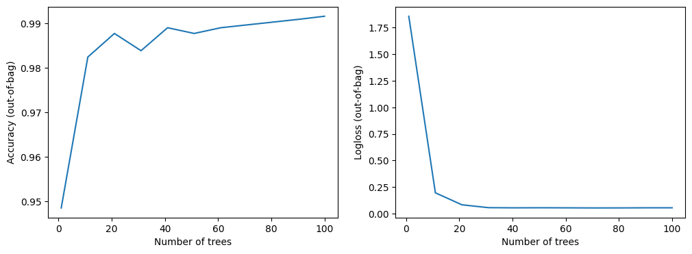

```python
import matplotlib.pyplot as plt

logs = model_1.make_inspector().training_logs()

plt.figure(figsize=(12, 4))

plt.subplot(1, 2, 1)
plt.plot([log.num_trees for log in logs], [log.evaluation.accuracy for log in logs])
plt.xlabel("Number of trees")
plt.ylabel("Accuracy (out-of-bag)")

plt.subplot(1, 2, 2)
plt.plot([log.num_trees for log in logs], [log.evaluation.loss for log in logs])
plt.xlabel("Number of trees")
plt.ylabel("Logloss (out-of-bag)")

plt.show()
```

## TensorFlow Keras Neural Network with Keras preprocessing layers

Finally, a deep learning model was built using TensorFlow Keras for multiclass classification. The model used the Adam optimizer and applied Keras preprocessing layers to the input data. Neural networks are powerful for capturing complex, nonlinear patterns, and this model was implemented to compare traditional machine learning models with a modern deep learning approach.

```python
import tensorflow as tf
from tensorflow.keras import layers
```

```python
tf.__version__
```

```
'2.18.0'
```

```python
# import random
from random import random

seed = 42
tf.random.set_seed(seed)
np.random.seed(seed)
```

```python
# Split the dataset into training and testing sets
train, val, test = np.split(df_tensorflow.sample(frac=1), [int(0.8*len(df)), int(0.9*len(df))])
```

```python
print(len(train), 'training examples')
print(len(val), 'validation examples')
print(len(test), 'test examples')
```

```
1760 training examples
220 validation examples
220 test examples
```

```python
# Function to convert a pandas DataFrame into a TensorFlow dataset

def df_to_dataset(dataframe, shuffle=True, batch_size=32):
  df = dataframe.copy()
  labels = df.pop('label')
  df = {key: value.to_numpy()[:,tf.newaxis] for key, value in dataframe.items()}
  ds = tf.data.Dataset.from_tensor_slices((dict(df), labels))
  if shuffle:
    ds = ds.shuffle(buffer_size=len(dataframe))
  ds = ds.batch(batch_size)
  ds = ds.prefetch(batch_size)
  return ds
```

```python
[(train_features, label_batch)] = train_ds.take(1)
print('Every feature:', list(train_features.keys()))
```

```
Every feature: ['N', 'P', 'K', 'temperature', 'humidity', 'ph', 'rainfall']
```

```python
def get_normalization_layer(name, dataset):
  # Create a Normalization layer for the feature.
  normalizer = layers.Normalization(axis=None)

  # Prepare a Dataset that only yields the feature.
  feature_ds = dataset.map(lambda x, y: x[name])

  # Learn the statistics of the data.
  normalizer.adapt(feature_ds)

  return normalizer
```

```python
# Set the batch size for training, validation, and testing datasets
# Create a TensorFlow dataset for the training data, validation data, and testing data

batch_size = 5
train_ds = df_to_dataset(train, batch_size=batch_size)
val_ds = df_to_dataset(val, shuffle=False, batch_size=batch_size)
test_ds = df_to_dataset(test, shuffle=False, batch_size=batch_size)
```

```python
# Initialize dictionaries to store input layers and encoded features
all_inputs = {}
encoded_features = []

# Process numerical features
for header in ['N', 'P', 'K','humidity','rainfall','ph', 'temperature']:
  numeric_col = tf.keras.Input(shape=(1,), name=header)
  normalization_layer = get_normalization_layer(header, train_ds)
  encoded_numeric_col = normalization_layer(numeric_col)
  all_inputs[header] = numeric_col
  encoded_features.append(encoded_numeric_col)
```

```python
encoded_features
```

```
[<KerasTensor: shape=(None, 1) dtype=float32 (created by layer 'normalization')>,
 <KerasTensor: shape=(None, 1) dtype=float32 (created by layer 'normalization_1')>,
 <KerasTensor: shape=(None, 1) dtype=float32 (created by layer 'normalization_2')>,
 <KerasTensor: shape=(None, 1) dtype=float32 (created by layer 'normalization_3')>,
 <KerasTensor: shape=(None, 1) dtype=float32 (created by layer 'normalization_4')>,
 <KerasTensor: shape=(None, 1) dtype=float32 (created by layer 'normalization_5')>,
 <KerasTensor: shape=(None, 1) dtype=float32 (created by layer 'normalization_6')>]
```

```python
# Concatenate all encoded features into a single tensor
all_features = tf.keras.layers.concatenate(encoded_features)

# Add a fully connected (dense) layer with 64 units and ReLU activation
x = tf.keras.layers.Dense(64, activation="relu")(all_features)

# Add a dropout layer to reduce overfitting
x = tf.keras.layers.Dropout(0.5)(x)

num_classes = 22  # Replace with the actual number of classes
output = tf.keras.layers.Dense(num_classes, activation="softmax")(x)

# Build the model
model = tf.keras.Model(all_inputs, output)
```

**On the ADAM Optimizer**

The author’s chose the ADAM optimizer for the TensorFlow model due to its advantageous characteristics in adjusting the learning rate for each parameter. ADAM utilizes the first moment (the average of past gradients) and the second moment (the uncentered variance of past gradients) to dynamically adapt the learning rates throughout training (Kingma, 2014). This feature allows for more efficient convergence, particularly in complex optimization landscapes.

Moreover, ADAM is widely recognized for its versatility and effectiveness across a variety of tasks, making it a reliable starting point for implementing neural networks. Its ability to handle sparse gradients and its robustness in different scenarios contribute to its popularity among practitioners (Kingma, 2014). Thus, the decision to use the ADAM optimizer was based on both its theoretical benefits and practical performance observed in numerous applications within the field of deep learning.

```python
# Compile the model by specifying the optimizer, loss function, and evaluation metrics

model.compile(
    optimizer='adam',
    loss=tf.keras.losses.SparseCategoricalCrossentropy(from_logits=False),
    metrics=["accuracy"],
    run_eagerly=True)
```

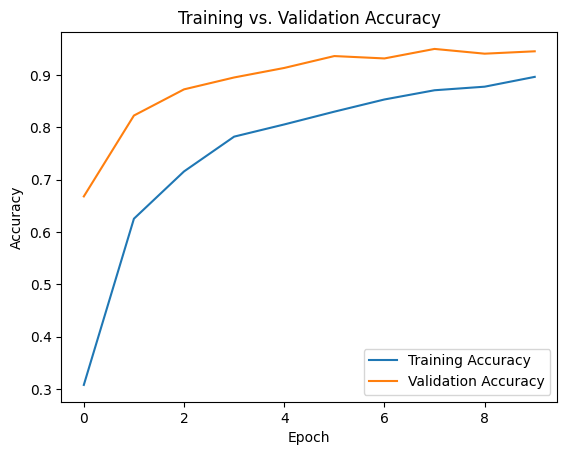

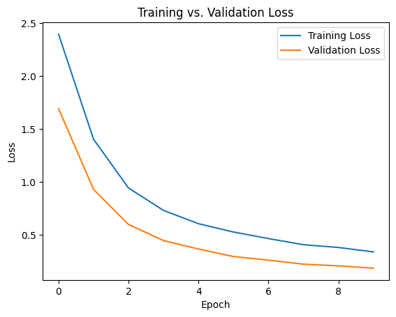

```python
# Define early stopping to halt training if validation loss does not improve for epochs
early_stopping = tf.keras.callbacks.EarlyStopping(
    monitor="val_loss",
    patience=5,
    restore_best_weights=True,
)

# Train the model with the training and validation datasets, using early stopping
history = model.fit(train_ds, epochs=10, validation_data=val_ds, callbacks=[early_stopping])

# Plot training accuracy vs. validation accuracy over epochs
plt.plot(history.history['accuracy'], label='Training Accuracy')
plt.plot(history.history['val_accuracy'], label='Validation Accuracy')
plt.xlabel('Epoch')
plt.ylabel('Accuracy')
plt.legend()
plt.title('Training vs. Validation Accuracy')
plt.show()

# Plot training loss vs. validation loss over epochs
plt.plot(history.history['loss'], label='Training Loss')
plt.plot(history.history['val_loss'], label='Validation Loss')
plt.xlabel('Epoch')
plt.ylabel('Loss')
plt.legend()
plt.title('Training vs. Validation Loss')
plt.show()
```

```python
# Evaluate on unseen test data
result = model.evaluate(test_ds, return_dict=True)
print(f"Test Accuracy: {result['accuracy']}")
print(f"Test Loss: {result['loss']}")
```

```
Test Accuracy: 0.9681817889213562
Test Loss: 0.19380873441696167
```

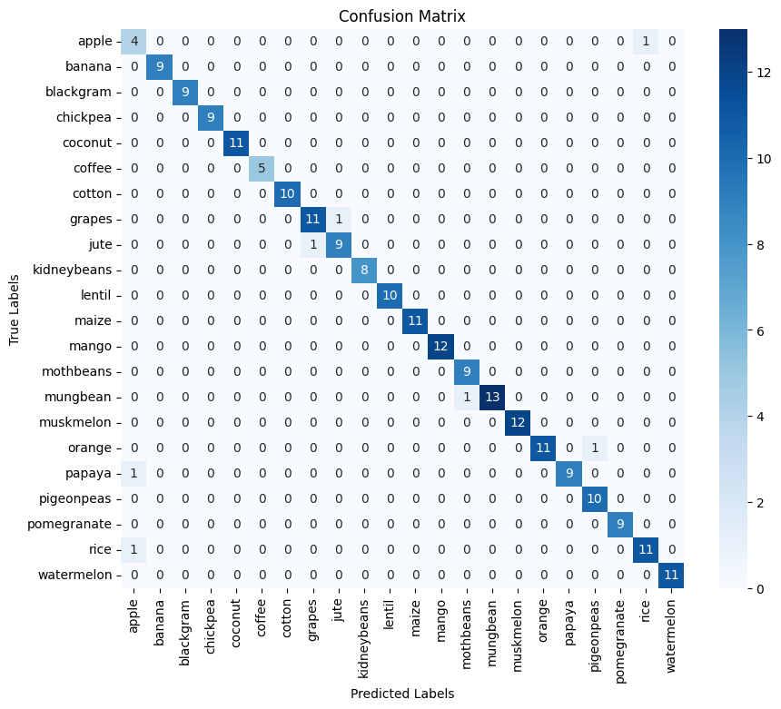

```
              precision    recall  f1-score   support

       apple       0.67      0.80      0.73         5
      banana       1.00      1.00      1.00         9
   blackgram       1.00      1.00      1.00         9
    chickpea       1.00      1.00      1.00         9
     coconut       1.00      1.00      1.00        11
      coffee       1.00      1.00      1.00         5
      cotton       1.00      1.00      1.00        10
      grapes       0.92      0.92      0.92        12
        jute       0.90      0.90      0.90        10
 kidneybeans       1.00      1.00      1.00         8
      lentil       1.00      1.00      1.00        10
       maize       1.00      1.00      1.00        11
       mango       1.00      1.00      1.00        12
   mothbeans       0.90      1.00      0.95         9
    mungbean       1.00      0.93      0.96        14
   muskmelon       1.00      1.00      1.00        12
      orange       1.00      0.92      0.96        12
      papaya       1.00      0.90      0.95        10
  pigeonpeas       0.91      1.00      0.95        10
 pomegranate       1.00      1.00      1.00         9
        rice       0.92      0.92      0.92        12
  watermelon       1.00      1.00      1.00        11

    accuracy                           0.97       220
   macro avg       0.96      0.97      0.96       220
weighted avg       0.97      0.97      0.97       220
```

```python
# Get true labels and predictions
true_labels = np.concatenate([y for x, y in test_ds], axis=0)
predictions = model.predict(test_ds)
predicted_labels = np.argmax(predictions, axis=1)  # Get predicted class indices

# Confusion matrix
cm = confusion_matrix(true_labels, predicted_labels)

# Plot confusion matrix
import seaborn as sns
plt.figure(figsize=(10, 8))
sns.heatmap(cm, annot=True, fmt='d', cmap='Blues', xticklabels=label_encoder.classes_, yticklabels=label_encoder.classes_)
plt.xlabel('Predicted Labels')
plt.ylabel('True Labels')
plt.title('Confusion Matrix')
plt.show()

# Classification report
report = classification_report(true_labels, predicted_labels, target_names=label_encoder.classes_)
print(report)
```

# VIII. Summary of Best Model Conguration and Model Metrics

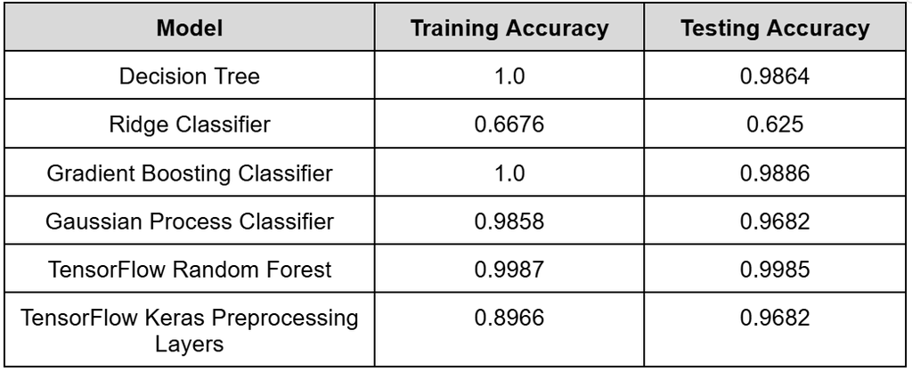

Aside from having favorable train & test results, the study factored in machine learning assumptions that supplement the utilization of the base model. It is important to note that the nature of the dataset Non-Stationary & Non-Linear. One of the assumptions of Decision Trees is that it offers flexibility in handling non-linear relationships. Decision trees split the data based on feature thresholds, which allows them to capture non-linear patterns in the data. This makes them well-suited for datasets with non-linear decision boundaries in classification tasks (Friedman et al, 2009).

**Chosen Crops: Top 3 in the Context of India**

The study will focus the following discussions relative to the most relevant crops in the context of India. The 3 crops include: (1) Rice, (2) Maize/Corn, and (3) Cotton.

**On the Relevance of Rice in the Indian Context**

Rice is a cornerstone of India’s agricultural landscape and plays a vital role in the country’s economy and food security. As of the 2024-2025 kharif season, India’s rice production is projected to reach a record 119.93 tonnes, reflecting a significant increase due to the favorable monsoon conditions and expanded cultivation areas across key states such as Uttar Pradesh and West Bengal (Sharma, 2024). It not only serves as the primary staple food for over 50% of the Indian population but also supports approximately 70 million farmers engaged in its cultivation (Anand, 2024). Furthermore, rice contributes significantly to rural livelihoods and is integral to the textile industry, which relies on rice by-products (Cotecna, 2024).

**On the Relevance of Maize in the Indian Context**

Maize is a crucial crop in India, serving as the third most important food grain after rice and wheat. In the 2023-2024 agricultural year, India produced approximately 32.47 million metric tons of maize, with major cultivation occurring in states like Karnataka, Madhya Pradesh, and Bihar (PJTSAU, 2024). The adaptability of maize to various climatic conditions allows it to be grown in both kharif (monsoon) and rabi (winter) seasons, making it a versatile crop that supports food security and agricultural diversity. Notably, about 47% of the maize produced is used as poultry feed, highlighting its significance in the livestock industry (Saini, 2024).

The potential for maize production in India is substantial, with estimates suggesting that the country could double its output in the coming years through improved agricultural practices and technology adoption. Currently, around 55-60% of maize is cultivated using single-cross hybrid seeds, which can yield significantly more than traditional varieties (Choudhary & Dass, 2024). This emphasis on maize not only supports domestic food needs but also positions India as a competitive player in the global market for maize products.

**On the Relevance of Cotton in the Indian Context**

Cotton plays an important rule in India’s economy, especially during the 19th century, serving as one of the key exports that significantly contributed to the country’s economic activity. As the second-largest exporter of cotton globally, India supplied nearly 30% of the world market, which made India one of the leading exporters and vital players in international trade alongside the United States (Ronnback & Theodoridis, 2022). It is considered a major raw material for the textile industry, which is one of the largest employment sectors in the country. This crop plays a key role in rural livelihoods, and supporting over 6 million farmers across India.

# IX. Explainability AI (after choosing Best Model)

## SHAP (Shapley Additive Explanations)

```
Class apple
```

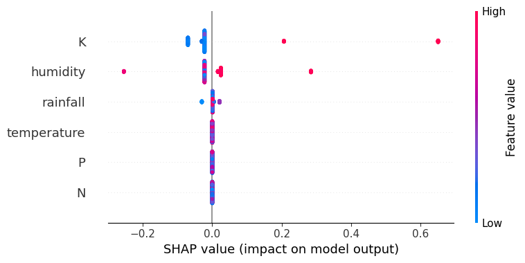

```
Class banana
```

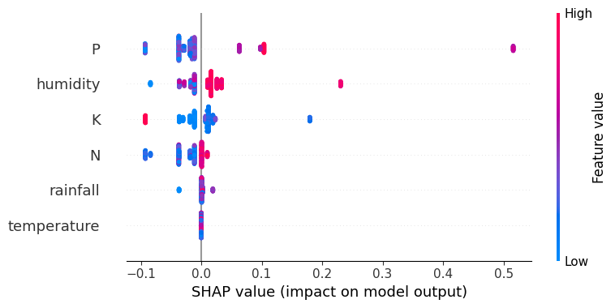

```
Class blackgram
```

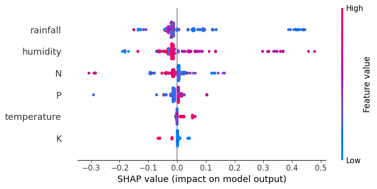

```
Class chickpea
```

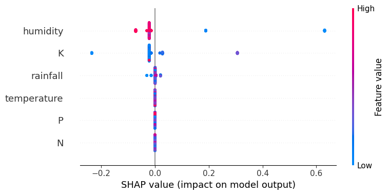

```
Class coconut
```

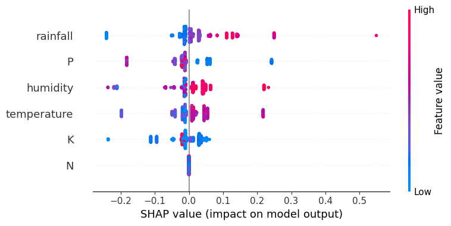

```
Class coffee
```

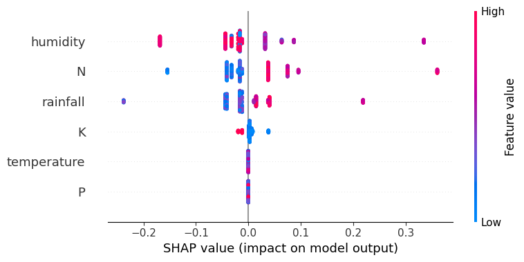

```
Class cotton
```

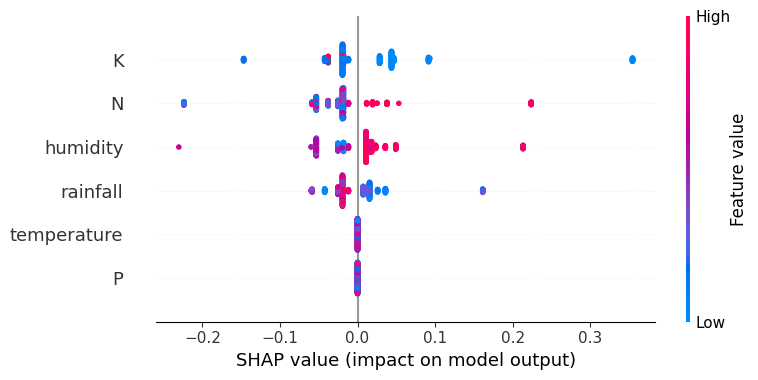

```
Class grapes
```

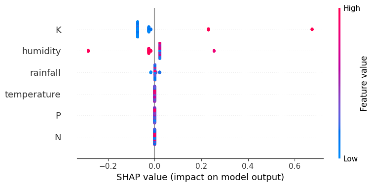

```
Class jute
```

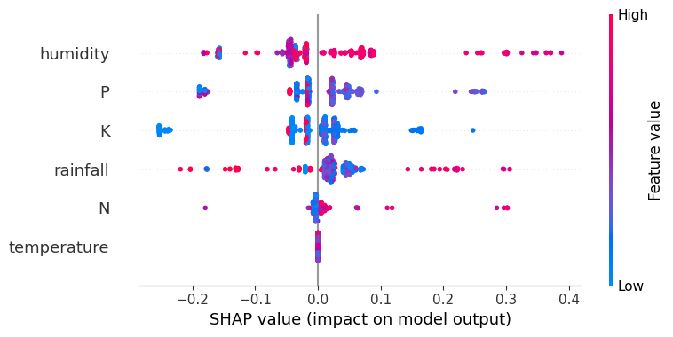

```
Class kidneybeans
```

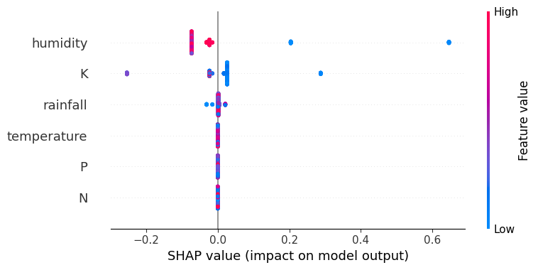

```
Class lentil
```

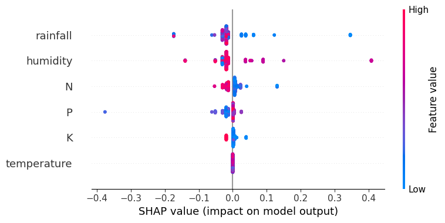

```
Class maize
```

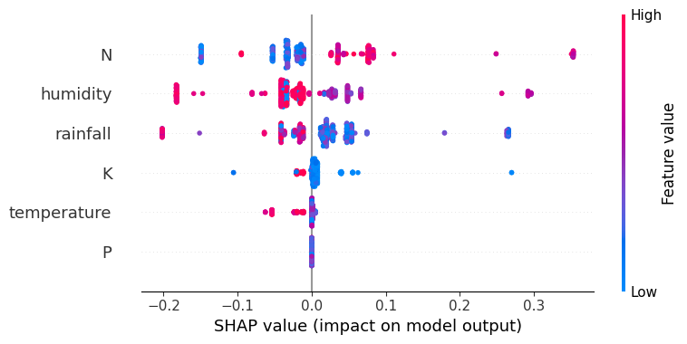

```
Class mango
```

[10 more figures not shown]

```python
# Initialize a SHAP TreeExplainer for the decision tree model (dt)
import shap

explainer_dt = shap.TreeExplainer(dt)
shap_values_dt = explainer_dt.shap_values(X_test_scaled)

#GLOBAL EXPLAINABILITY
classes = shap_values_dt.shape[2]

# Loop through each class to visualize feature importance for each one
for i in range(classes):
    print(f"Class {label_encoder.classes_[i]}")
    shap.summary_plot(shap_values_dt[:, :, i], X_test_scaled, feature_names=X.columns)
    plt.show()
```

## Discussion on SHAP Results for the Chosen Crops

**SHAP Analysis: Rice**

The SHAP analysis indicates that high humidity values are distributed both above and below the 0 mark on the SHAP value axis. This suggests that moderate humidity levels can positively influence the model’s predictions for rice. However, extreme humidity levels—whether too high or too low—can lead to adverse effects on plant health, potentially increasing the risk of diseases that negatively impact yield.

The analysis shows that low feature values for rainfall predominantly fall below zero, indicating that insufficient rainfall is detrimental to rice yields. While some higher feature values appear above zero, they are less influential compared to the lower values clustered below 0. This pattern suggests that rice requires adequate moisture for optimal growth, but excessive rainfall can lead to issues such as waterlogging and root damage.

The SHAP plot reveals that high phosphorus values are mostly located below zero, indicating a negative impact on the model's predictions for rice. The plot is primarily colored in blue or purple, suggesting that phosphorus does not significantly enhance the model’s predictions. This could imply that while phosphorus is essential for plant development, its variability may not be sufficient to drive substantial improvements in rice yield outcomes.

The analysis indicates that there are 5 to 6 dots of high feature importance for potassium positioned below zero. This suggests that higher potassium levels negatively affect the model’s predictions for rice. In contrast, low potassium values are clumped above zero but also intermingle with higher importance values below zero. This indicates that while low potassium levels may not significantly harm yield predictions, excessive potassium can lead to nutrient imbalances detrimental to rice health.

The results show that nitrogen has low feature importance slightly above zero but remains close to the 0 line. There are some instances of higher feature importance appearing in the analysis, indicating that while nitrogen is important for rice growth, its impact on yield predictions is less pronounced compared to other factors like humidity and rainfall.

The temperature feature displays a mix of blue (low importance), red (high importance), and purple (medium importance) dots around the 0 line. This distribution suggests that temperature has a variable influence on rice yields; while certain temperature ranges may be beneficial for growth, overall fluctuations do not significantly affect the model's predictions.

**Consistency of SHAP Results With the Rice Crop**

The analysis reveals critical threshold effects for phosphorus and potassium, where low to moderate levels support rice growth, but excessive amounts can lead to detrimental outcomes. Studies have highlighted that phosphorus, while essential for plant development, can become harmful at high concentrations, leading to nutrient imbalances that affect crop health. Similarly, potassium's beneficial effects are limited to certain levels; beyond this point, it can negatively impact rice health. The stable influence of temperature and the variable effects of humidity further emphasize the complexity of managing these factors for optimal rice cultivation. These findings collectively underscore the necessity for precise nutrient management strategies tailored to specific environmental conditions to enhance rice production sustainably (Babu and Reddy, 2020).

**SHAP Analysis: Maize**

The SHAP analysis reveals that nitrogen has high feature importance above the 0 mark, indicating that elevated nitrogen levels positively influence the model’s predictions for maize. Conversely, low nitrogen values are associated with low feature importance below 0, suggesting that insufficient nitrogen can significantly hinder maize growth and yield.

The analysis shows that phosphorus exhibits low to medium feature importance concentrated around the 0 line. This indicates that variations in phosphorus levels have a minimal impact on the model's predictions for maize, suggesting that while phosphorus is necessary for plant development, its influence may not be as critical compared to other nutrients.

For potassium, the SHAP values indicate low feature importance above 0, with some evidence of high feature importance reflected in 2-3 dots below 0. This suggests that while potassium levels may not be as influential at higher concentrations, excessive potassium could negatively affect maize yields.

Humidity shows high feature importance below 0 and medium importance above 0. This pattern implies that while high humidity levels can negatively affect maize yields—potentially due to increased disease risk—moderate humidity may still play a beneficial role in supporting growth.

**Consistency of SHAP Results with the Maize Crop**

Nitrogen's critical role in yield improvement is widely recognized, as it enhances biomass and grain production through its influence on photosynthesis and chlorophyll synthesis. Optimal application rates are essential, as over-fertilization reduces efficiency and can harm yields. This supports your SHAP findings showing high feature importance for nitrogen within optimal levels but diminished importance at extremes (Frontiers, 2023).

**SHAP Analysis: Cotton**

In the graph, high feature values for potassium are predominantly located below 0 on the SHAP value axis, this suggests that higher potassium levels negatively impact the model’s predictions for cotton. On the other hand, low feature values for potassium cluster slightly above the 0 SHAP values, implying that they contribute neutrally to the model’s output. While potassium content proves crucial for plant growth, excess potassium may cause imbalances in other essential nutrients.

In the context of nitrogen, high nitrogen levels enhance the model’s predictions, implying nitrogen levels are important for cotton. On the contrary, low nitrogen levels consistently lower the model’s predictions. Nitrogen is essential for vegetative growth and chlorophyll formation in cotton plants, which further supports the results.

Moving on to humidity, high humidity has a positive influence, however extremely high levels of humidity can occasionally have a negative effect, possibly due to disease risks to the cotton plant. On the contrary, low humidity reduces the model’s predictions significantly. Moderate humidity is beneficial for cotton growth, particularly during the flowering stages.

For rainfall, initially higher rainfall leads to a positive influence, but only up to a certain threshold, after which the impact turns negative. Lower rainfall has a stronger impact and positive influence on the model’s predictions. Cotton requires consistent water supply during critical stages such as germination, however too much rainfall would require drainage systems to avoid overwattering and root damage to the cotton plant.

Both features of temperature and phosphorus (P) are centered around the 0.0 SHAP value mark, which suggests that these features do not significantly influence the model’s predictions for the cotton crop outcome. Despite the features having both high and low feature value, their contribution to the model’s output is negligible. Possibly, their influence might be overshadowed by the other factors such as potassium, nitrogen, humidity, and rainfall. Moreover, checking the dataset, there lacks variability in temperature and phosphorus values for cotton, which could affect the model in detecting any variable pattern or impact.

**Consistency of the SHAP Results with the Cotton Crop**

The SHAP analysis aligns with the biological requirements and challenges associated with growing cotton. Potassium is vital for cotton plant metabolism, especially in stress resilience, but excess levels can interfere with the uptake of other critical nutrients, potentially harming growth. Nitrogen, on the other hand, directly supports vegetative growth and photosynthesis, and its SHAP results emphasize its importance in driving favorable outcomes for cotton cultivation. This resonates with its role in promoting foliage and chlorophyll synthesis, essential for the plant's productivity (Saini et al., 2023).

According to Yang et al. (2024), humidity’s influence in the SHAP results mirrors the cotton plant’s sensitivity to its environment. Moderate humidity facilitates flowering and boll development, but excessive humidity can trigger fungal diseases like boll rot, while low humidity exacerbates water stress. Rainfall results reflect cotton's need for balanced irrigation: adequate water during germination and flowering is essential, yet excessive rainfall can lead to root damage and disease, emphasizing the importance of drainage systems in cotton fields.

```python
def make_shap_waterfall_plot(shap_values, features, num_display=20, figsize=(10, 8), color='blue', alpha=0.6):

    # Define the feature names inside the function
    default_feature_names = ['N', 'P', 'K', 'temperature', 'humidity', 'rainfall']

    # Handle multiclass SHAP values by aggregating across classes
    if shap_values.ndim == 3:
        shap_values = shap_values.mean(axis=2)  # Aggregate across classes

    # Handle feature names
    if isinstance(features, np.ndarray):
        column_list = default_feature_names  # Use default feature names if provided data is an array
    else:
        column_list = features.columns if features.columns is not None else default_feature_names

    # Ensure column_list is a numpy array
    column_list = np.array(column_list)

    # Calculate feature contributions
    feature_ratio = (np.abs(shap_values).sum(0) / np.abs(shap_values).sum()) * 100

    # Ensure feature_ratio is the same length as column_list
    if len(feature_ratio) != len(column_list):
        raise ValueError("Mismatch between the number of features in shap_values and the provided feature names")

    # Sort indices and check if they are integers
    sorted_indices = np.argsort(feature_ratio)[::-1]

    # Ensure num_display does not exceed available features
    num_display = min(num_display, len(column_list))

    # Debugging outputs
    print("Feature names:", column_list)
    print("Feature ratios:", feature_ratio)
    print("Sorted indices:", sorted_indices)

    column_list = column_list[sorted_indices][:num_display]
    feature_ratio_order = feature_ratio[sorted_indices][:num_display]
    cum_sum = np.cumsum(feature_ratio_order)

    # Adjust height dynamically based on the number of features displayed
    num_height = max(0, (len(column_list) - 20) * 0.4)

    # Create the plot
    fig, ax1 = plt.subplots(figsize=(figsize[0], figsize[1] + num_height))

    # Plot cumulative ratio line
    ax1.plot(cum_sum[::-1], column_list[::-1], color=color, marker='o', label='Cumulative Ratio')
    ax1.set_xlabel('Cumulative Ratio (%)', fontsize=12)
    ax1.set_xticks(np.arange(0, round(cum_sum.max(), -1) + 1, 10))
    ax1.grid(True, linestyle='--', alpha=0.7)
    ax1.tick_params(axis='y', labelsize=12)

    # Plot bar chart for feature contributions
    ax2 = ax1.twiny()
    ax2.barh(column_list[::-1], feature_ratio_order[::-1], alpha=alpha, color=color, label='Feature Contribution')
    ax2.set_xlabel('Feature Contribution (%)', fontsize=12)
    ax2.set_xticks(np.arange(0, round(feature_ratio_order.max(), -1) + 1, 10))
    ax2.grid(False)

    # Plot legend
    fig.legend(loc='upper right', fontsize=12)

    # Set plot limits and title
    plt.ylim(-1, len(column_list))
    plt.title('SHAP Value Waterfall Plot', fontsize=14, pad=20)

    plt.show()
```

```
Feature names: ['N' 'P' 'K' 'temperature' 'humidity' 'rainfall']
Feature ratios: [ 7.25597696 17.5659728  24.09984568  1.43045381 31.8925179  17.75523285]
Sorted indices: [4 2 5 1 0 3]
```

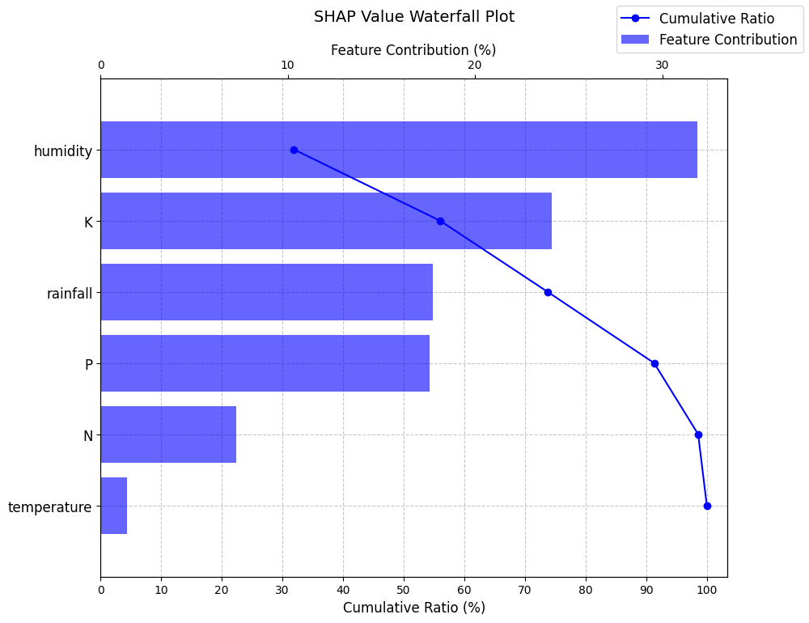

```python
# Plot SHAP Waterfall Plot
make_shap_waterfall_plot(shap_values_dt, X_test_scaled)
```

**Discussion on the SHAP Waterfall Plot**

As seen in the graph, this indicates that the highest feature importance is Humidity, whereas the lowest feature importance is Temperature.

When it comes to temperature and humidity, according to Gray (2018), temperature significantly influences the humidity levels of crops like cotton, rice, and corn, primarily through its effect on evapotranspiration, a process combining soil evaporation and plant transpiration. Higher temperatures increase evapotranspiration rates, which can lower soil and atmospheric moisture, reducing relative humidity around crops. This can stress plants, especially in areas with limited water availability. As temperatures rise, plants may lose water more rapidly through their stomata, further decreasing local humidity levels. This is particularly impactful for water-intensive crops like rice, which thrive in moist environments. Reduced humidity under high temperatures can lead to stunted growth or lower yields due to insufficient water for optimal photosynthesis (Gray, 2018). High temperatures often accelerate crop maturation, shortening growing seasons and limiting the time plants have to accumulate resources, which can indirectly affect water retention and humidity balance in the crop canopy (Gray, 2018). For example, corn, which grows extensively in temperate climates, shows reduced productivity under heat stress due to faster drying of soils.

On the contrary, humidity also plays a vital role in moderating temperatures in crop environments for rice, corn, and cotton, directly impacting their growth. High humidity in these environments reduces the loss of heat from the soil and plants during the night, helping to maintain more stable temperatures. This stability is particularly beneficial for rice, a water-intensive crop that thrives in consistently warm and moist conditions. According to Chia & Lim (2022), during the day, high humidity can amplify heat stress by slowing the evaporation of water from plant surfaces, potentially increasing the apparent temperature. This can affect crops like cotton and corn, which are sensitive to prolonged high temperatures and may experience reduced photosynthesis rates under such conditions. Conversely, lower humidity can cause faster cooling and drying of the soil and plants, which might be beneficial for crops like cotton that prefer drier conditions but detrimental for rice, which relies on sustained moisture.

Despite temperature and humidity complementing each other, the researchers think that they are on opposite ends of the spectrum due to *limited data variability* specifically for temperature in the dataset, which can be observed from the descriptive statistics, and thus affecting the model’s results. Given this relationship between temperature and humidity, it is also possible that humidity may already be implied from temperature. This could give us an assumption that the measure for temperature is already implied in the results, since temperature’s impact might already be implied indirectly in the context of its correlation with humidity. This could also be a potential reason as to why temperature is insignificant throughout the models.

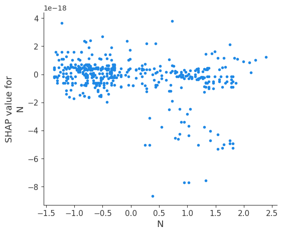

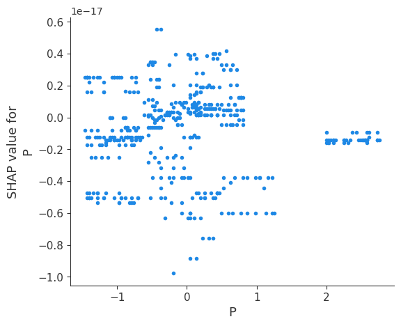

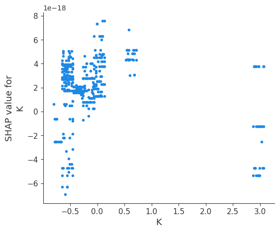

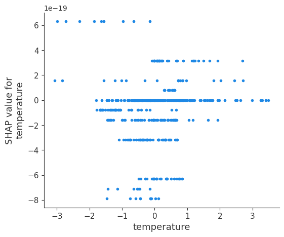

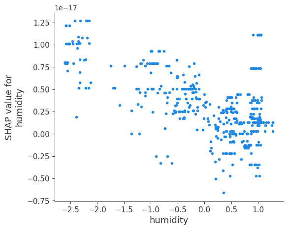

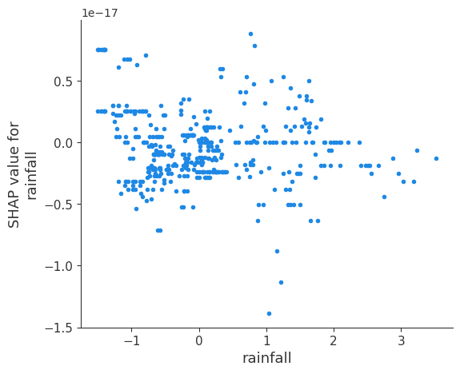

```python
# Plot SHAP Dependence Plots
default_feature_names = ['N', 'P', 'K', 'temperature', 'humidity', 'rainfall']
for i, feature_name in enumerate(default_feature_names):
    if shap_values_dt.ndim == 3:
      shap_values_dt = shap_values_dt.mean(axis=2)
    shap.dependence_plot(
        ind=i,  # Use the index of the feature
        shap_values=shap_values_dt,
        features=X_test_scaled,
        feature_names=default_feature_names, # Set custom feature names
        interaction_index=None)
```